# Introdução à Ciência de Dados

Mestrado Profissional em Administração

Prof. Washington Santos da Silva

IFMG - Campus Formiga

26 de junho de 2025

## Diário de Bordo

**O que vimos até aqui?**

- Aula 1 ✅
  - Apresentação da Disciplina ✅
  - Introdução e Contextualização ✅
  - O que é Ciência de Dados? ✅
  - Pesquisa Reproduzível e Ciência de Dados ✅
  - Papéis Profissionais ✅
  - Aplicações ✅
  - Habilidades Interpessoais e Analíticas ✅
  - Apresentação da Disciplina ✅
  - Configurações: Git/GitHub ✅
- Aula 2 ✅
  - Metodologia CRISP-DM ✅
  - Tipos de Análise de Dados ✅
  - Introdução ao RStudio e criação do **seu** Projeto da Disciplina ✅
  - Introdução ao Sistema de Publicação Quarto ✅
  - Introdução ao Git e GitHub: controle de versão e criação do **seu** repositório no GitHub ✅
- Aula 3 ✅
  - Breve Revisão sobre o RStudio ✅
  - Sistema de Publicação Quarto: (Cont.) ✅
  - Introdução ao Git e GitHub: (Cont.) ✅
  - Sessão Prática: Fluxo de trabalho integrando RStudio/Quarto/R/Git/GitHub ✅
- Aula 4 ✅
  - Conceitos de Variáveis e Observações em Estatística ✅
  - Conceito de Dados Organizados (*Tidy Data*) ✅
  - Tipos atômicos e classes principais de dados da linguagem R ✅
  - Tipos de Dados Tradicionais em Finanças: ✅
    - Dados em Secção-Cruzada (ou Transversal) (*Cross-Section Data*) ✅
    - Dados em Secções-Cruzadas Combinadas (*Pooled Cross-Section Data*) ✅
    - Dados em Séries Temporais (*Time Series Data*) ✅
    - Dados em Painel (ou Longitudinais) (*Panel Data*) ✅
  - Importação e Preparação de Dados Típicos de Finanças com exemplos práticos ✅
- Aula 5 ✅
  - Metodologia CRISP-DM: Fases 2 e 3 ✅
  - Revisão sobre Dados Organizados (*Tidy Data*) ✅
  - Introdução ao Pacote tidyr: função pivot_longer() ✅
  - Introdução ao Pacote dplyr: funções select() e filter() ✅
  - Exercícios ✅
- Aula 6 ✅
  - Função mutate ✅
  - Funções group_by e summarize ✅
  - Exercícios ✅
- Aula 7 ✅
  - Introdução ao Pacote dplyr: Tipos Básicos de *joins* ✅
  - Exercícios ✅
- Aula 8 ✅
  - Modelos
  - Conceitos Fundamentais de Probabilidade
    - O que é Probabilidade?
    - Probabilidade Condicional e Independência
    - Amostra Aleatória
    - Variáveis Aleatórias e Funções de Probabilidade
    - Função de Distribuição Acumulada
    - Lei dos Grandes Números
  - Distribuições de Probabilidade de VA Discretas
    - Distribuição de Bernoulli
    - Características de uma Distribuição de Probabilidade
      - Valor Esperado
      - Variância e Desvio-Padrão
      - Assimetria e Curtose
  - Distribuição Binomial
  - Distribuições de Probabilidade de VA Contínuas
    - Teorema Central do Limite
    - Distribuição Normal

## Na Última Aula

**Tópicos - Fundamentos de Probabilidade e Simulação**

- Modelos
- Conceitos Fundamentais de Probabilidade
  - O que é Probabilidade?
  - Probabilidade Condicional e Independência
  - Amostra Aleatória
  - Variáveis Aleatórias e Funções de Probabilidade
  - Função de Distribuição Acumulada
  - Lei dos Grandes Números
- Distribuições de Probabilidade de VA Discretas
  - Distribuição de Bernoulli
  - Características de uma Distribuição de Probabilidade
    - Valor Esperado
    - Variância e Desvio-Padrão
    - Assimetria e Curtose
  - Distribuição Binomial
- Distribuições de Probabilidade de VA Contínuas
  - Teorema Central do Limite
  - Distribuição Normal

## Nesta Aula

**Tópicos - Fundamentos de Probabilidade e Simulação**

- Simulação de Monte Carlo - Aplicações
- Aplicação - Valor-em-Risco (VaR)
  - Pacote tidyquant, Séries de Preços e de Rretornos de Acões
  - Método Paramétrico
  - Método Histórico
  - Método de Simulação de Monte Carlo
- Aplicação - CVaR (*Conditional Value at Risk*, *Expected Shortfall*)

**Diretrizes para Aulas Mais Produtivas**

⌨️ **Código com método:**

95% dos erros são evitáveis com:

- Atenção na digitação
- Respeitar a sequência lógica de etapas
- Revisão antes de pedir ajuda

🤝 **Inteligência colaborativa:**

- Compartilhe conhecimento
- Resolva questões técnicas simples com colegas próximos
- Reserve ao professor as dúvidas conceituais complexas

💪 **Capacidade de Resolver Problemas**

Cada erro resolvido é uma evolução da sua habilidade analítica

# Simulação de Monte Carlo: Aplicações

## Simulação de Monte Carlo

**Fundamentos Teóricos**

##### **Essência matemática da simulação**

Transformamos o valor esperado teórico em um **estimador empírico** via amostragem aleatória:

$$\theta = E[g(X)]
\;\;\approx\;\;
\hat\theta_N = \frac{1}{N} \sum_{i=1}^N g(X_i),
\quad \text{com } X_i \overset{\text{i.i.d.}}{\sim} f_X$$

> **Simular** = gerar amostras pseudo-aleatórias e calcular a média.

##### **Por que funciona? Convergência Estatística**

| Conceito | Enunciado (intuitivo) | Implicação prática |
| --- | --- | --- |
| **Lei dos Grandes Números (LLN)** | $\hat\theta_N \to \theta$ quando $N \to \infty$ | O estimador é **consistente** |
| **Teorema Central do Limite (TCL)** | $\hat\theta_N \overset{d}{\longrightarrow} N(\theta, \sigma^2 / N)$ | Podemos **quantificar o erro** da estimativa |
| **Erro-Padrão (EP)** | $V\text{ar}(\hat\theta_N) = \sigma^2/N \;\Rightarrow\; \text{EP} = \sigma / \sqrt{N}$ | Estimamos incerteza e construímos **intervalos de confiança** |
| **Erro de MC** | $\text{EP} \propto 1/\sqrt{N}$ | Dobrar $N$ ↓ erro ≈ 29%; quadruplicar ↓ erro 50% |

##### **Visualizando a Convergência**

$$\underbrace{
\hat\theta_N = \frac{1}{N} \sum_{i=1}^{N} g(X_i)
}_{\text{média amostral}}
\quad
\overset{d}{\longrightarrow}
\quad
N \left(
\theta, \frac{\sigma^2}{N}
\right)
\quad \text{com } \sigma^2 = V\text{ar}[g(X)]$$

##### **Fluxo “5 E” Clássico da Simulação**

1. **Especificar** o modelo $f_X$
2. **Extrair** amostras $X_1,\dots,X_N$
3. **Estimar** a estatística $\hat\theta_N$
4. **Estimar** o erro via TCL ou bootstrap
5. **Elevar** a eficiência com técnicas de redução de variância

## Quando Usar Simulação de Monte Carlo?

**Critérios de Aplicação**

✅ Use Monte Carlo quando:

- **Múltiplas incertezas simultâneas**: vários parâmetros incertos
- **Distribuições não-padrão**: triangular, uniforme, assimétricas
- **Necessidade de quantificar risco**: P(perda), percentis, cenários extremos
- **Correlações entre variáveis**: inflação × juros, receita × custos

❌ Evite Monte Carlo quando:

- **Solução analítica simples existe**: fórmulas fechadas suficientes
- **Incerteza mínima**: parâmetros bem conhecidos
- **Tempo/recursos limitados**: urgência na decisão

**Exemplos Práticos:**

| Situação | Método Recomendado | Justificativa |
| --- | --- | --- |
| VPL com taxa fixa e fluxos certos | **Determinístico** | Sem incerteza significativa |
| Projeto com 5+ parâmetros incertos | **Monte Carlo** | Múltiplas fontes de risco |
| Análise rápida de sensibilidade | **Cenários** | Simplicidade e velocidade |

💡 **Regra prática**: Se você tem múltiplas incertezas OU precisa quantificar probabilidades de risco, use Monte Carlo.

## Monte Carlo vs. Análise de Sensibilidade Tradicional

**Comparando Abordagens**

**Análise de Sensibilidade (3 cenários):**

```
Pessimista: VPL = -R$ 15.000
Base:       VPL = +R$ 2.600
Otimista:   VPL = +R$ 22.000
```

✅ **Vantagens**: Simples, rápida  
❌ **Limitações**: Apenas 3 pontos, sem probabilidades

**Simulação de Monte Carlo (100.000 cenários):**

```
P(VPL > 0) = 73%              → probabilidade de sucesso
P(VPL < -10.000) = 8%        → risco de perda severa
VPL médio = R$ 3.200          → retorno esperado
Percentil 5% = -R$ 12.500     → pior caso provável
```

✅ **Vantagens**: Informação completa sobre risco  
❌ **Limitações**: Mais complexa

**Qual informação é mais útil para decidir?**

| Pergunta do Gestor | Sensibilidade | Monte Carlo |
| --- | --- | --- |
| “Qual a chance de sucesso?” | ❌ “Depende do cenário” | ✅ “73% de probabilidade” |
| “Quanto posso perder?” | ❌ “Até R$ 15.000” | ✅ “95% chance: perda < R$ 12.500” |
| “Vale o risco?” | ❌ Subjetivo | ✅ Quantificado |

💡 Monte Carlo fornece exatamente as informações que gestores precisam para decisões sob risco.

## Aplicações Essenciais de Monte Carlo em Finanças

**Onde é Padrão da Indústria**

**💼 Análise de Viabilidade de Projetos de Investimento**

- **Análise de VPL** com múltiplas incertezas
- **Orçamento de capital** sob risco
- **Opções reais** (expandir, abandonar projeto)

**📊 Gestão de Risco**

- **Value-at-Risk (VaR)**: perdas máximas prováveis
- **Stress testing**: cenários de crise
- **Risco de crédito**: probabilidade de calote

**🏛️ Setores que Utilizam Métodos de Monte Carlo no Brasil**

| Setor | Aplicações Típicas | Vantagens e Necessidade | Casos Brasileiros |
| --- | --- | --- | --- |
| **Bancos & Finanças** | - Cálculo de capital regulatório (Basileia III) - Stress testing de carteiras - Avaliação de derivativos | - Exigência do BCB - Modelagem de riscos correlacionados - Precificação de instrumentos complexos | Itaú, Bradesco, Banco Central do Brasil |
| **Seguradoras & Resseguradoras** | - Cálculo de reservas técnicas - Modelagem de catástrofes naturais - Solvência (SUSEP) | - Normas CNSP - Eventos de baixa probabilidade/alto impacto - Agregação de riscos múltiplos | IRB Brasil RE, Porto Seguro |
| **Óleo & Gás** | - Avaliação de reservas (P50/P90) - Análise de viabilidade econômica - Gestão de projetos offshore | - Incerteza geológica - Volatilidade de preços - Otimização E&P | Petrobras, Pré-Sal, ANP |
| **Mineração** | - Avaliação de jazidas - Análise de viabilidade - Gestão de commodities | - Variabilidade de teores minerais - Exposição a preços internacionais - Longo ciclo de investimento | Vale, CBMM (Nióbio) |
| **Energia** | - Previsão de geração eólica/solar - Precificação de energia - Planejamento de expansão | - Intermitência de fontes renováveis - Modelagem hidrológica - Contratos de longo prazo | EPE, Operadores do SIN |
| **Agronegócio** | - Cálculo de seguros rurais - Previsão de safras - Gestão de riscos climáticos | - Exposição a intempéries - Volatilidade de commodities - Modelagem espaço-temporal | MAPA, Embrapa, Seguradoras |

**🎯 Por que esses setores usam?**

- **Alto risco financeiro** nas decisões
- **Regulamentação** exige quantificação de risco
- **Vantagem competitiva** na análise sofisticada

**Resultado**: Simulação de Monte Carlo não é uma técnica acadêmica, é **ferramenta de trabalho** em finanças corporativas.

## O Problema da Incerteza em Decisões Financeiras

**Cenário Típico: Avaliação de Projeto**

**Análise Tradicional (Determinística)**:

- Investimento: R$ 75.000 | Receita anual: R$ 15.000 (8 anos) | Taxa: 12%
- **VPL = R$ 2.600** → Projeto viável ✅

**Realidade: Múltiplas Incertezas**

**Pergunta crítica**: Qual a probabilidade real de sucesso?

**Limitações da análise determinística**:

- Ignora a **distribuição** de resultados possíveis
- Não quantifica o **risco de insucesso**

💡 **Solução**: Simulação de Monte Carlo quantifica a incerteza/risco.

## Análise de Viabilidade Econômica sob Incerteza

**Distribuição Triangular**

- A [distribuição triangular](https://pt.wikipedia.org/wiki/Distribui%C3%A7%C3%A3o_triangular) é amplamente utilizada em simulações de Monte Carlo, especialmente em estudos de viabilidade econômica e financeira, devido às suas características únicas e aplicabilidade prática.
- Função Densidade de Probabilidade

$$f(x) = \begin{cases}
\frac{2(x-a)}{(b-a)(c-a)} & \text{para } a \leq x < c, \\
\frac{2(b-x)}{(b-a)(b-c)} & \text{para } c \leq x \leq b, \\
0 & \text{caso contrário}.
\end{cases}$$

- Valor Esperado (ou média):

$$E(X) = \frac{a + b + c}{3}$$

- Variância

$$V(X) = \frac{a^2 + b^2 + c^2 - ab - ac - bc}{18}$$

## Distribuição Triangular

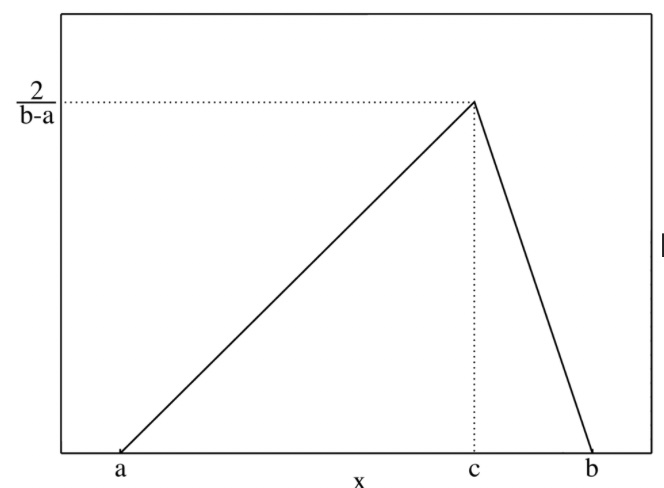

Função Densidade de Probabilidade

## Por que a Distribuição Triangular?

**Condições Adequadas para Uso da Distribuição Triangular**

- **Dados Limitados ou Incerteza Significativa**

A distribuição triangular é particularmente útil quando os dados são escassos ou quando há uma grande incerteza sobre as estimativas das variáveis. Ela é ideal para modelar variáveis com estimativas baseadas em opiniões de especialistas ou quando se tem apenas uma ideia geral sobre os limites superior e inferior e uma estimativa razoável do valor mais provável.

- **Projetos com Escopo Bem Definido, mas com Parâmetros Incertos**

Em projetos de investimento onde o escopo é conhecido (por exemplo, desenvolvimento de um novo produto, construção civil), mas os parâmetros individuais são incertos, a distribuição triangular ajuda a modelar os riscos associados a esses parâmetros de forma eficaz.

- **Análise Preliminar de Viabilidade**

A distribuição triangular é ideal para análises preliminares, onde a rapidez e a facilidade de implementação são importantes, e a precisão absoluta dos resultados da simulação pode não ser crítica.

## Distribuição Triangular em R

**Tabela de Parâmetros**

| Parâmetro | Descrição |
| --- | --- |
| **a** | Limite mínimo (cenário pessimista) |
| **b** | Limite máximo (cenário otimista) |
| **c** | Moda (valor mais provável) |
| **n** | Número de simulações |

- Em R:

```r
library(triangulr)
rtri(n, a, b, c)
```

## Escolha de Distribuições em Simulações Financeiras

**Quando Usar Cada Distribuição?**

| Distribuição | Quando Usar | Parâmetros | Exemplo Prático |
| --- | --- | --- | --- |
| **Uniforme** | Incerteza total; todos os valores igualmente prováveis | min, max | Receitas anuais entre R$ 12-16 mil |
| **Triangular** | Opinião de especialistas; valor mais provável conhecido | min, max, moda | Tempo de projeto: 9-11 anos (mais provável: 10) |
| **Normal** | Fenômenos naturais; erros de medição; agregações | média, desvio | Retornos de ativos; inflação |

**Diretrizes Práticas**:

**Use Uniforme quando**:

- Não há informação sobre qual valor é mais provável
- Cenário de “pior caso” vs “melhor caso” equiprováveis
- Análise conservadora de sensibilidade

```r
# Receitas podem variar igualmente entre os extremos
receitas <- runif(n, 12000, 16000)
```

**Use Triangular quando**: - Especialistas podem estimar min, max e “mais provável” - Parâmetros de projetos com base em experiência - Dados históricos limitados, mas há conhecimento do setor

```r
# Tempo de construção: experiência sugere 10 meses como mais provável
tempo <- rtri(n, 9, 11, 10)
```

**Use Normal quando**:

- Retornos financeiros (com cuidado nas caudas)
- Variáveis que são somas de muitos fatores pequenos
- Dados históricos abundantes sugerem normalidade

```r
# Retornos de portólio diversificado
retornos <- rnorm(n, 0.08, 0.12)
```

**⚠️ Cuidado**: Nunca use Normal para variáveis que não podem ser negativas (preços, quantidades) sem truncamento adequado.

## Análise de Insolvência via Simulação de Monte Carlo

**Fator de Insolvência de Kanitz**

**Origem:** Desenvolvido por Stephen Kanitz (Kanitz, 1978) para empresas brasileiras.

**Fórmula:**

$$FI = 0,05A + 1,65B + 3,55C – 1,06D – 0,33E$$

**Indicadores:**

- $A =$ Rentabilidade do PL: lucro líquido / patrimônio líquido
- $B =$ Liquidez Geral: (AC + RLP) / exigível total
- $C =$ Liquidez Seca: (AC - estoques) / passivo circulante
- $D =$ Liquidez Corrente: ativo circulante / passivo circulante
- $E =$ Grau de Endividamento: passivo total / patrimônio líquido

**Interpretação:**

- $FI > 0$: **Solvente** (baixo risco)
- $-3 \leq FI \leq 0$: **“Penumbra”** (risco moderado)
- $FI < -3$: **Insolvente** (alto risco)

**Por que simular?** Os indicadores financeiros têm incerteza. A simulação quantifica o **risco de classificação incorreta**.

## Fator de Insolvência de Kanitz

**Simulação em R**

```r
# ==================================================
# Fator de Insolvência de Kanitz - Simulação em R
# ==================================================

# Fixa a semente para reprodutibilidade
set.seed(2024)

# Número de simulações
n_simulacoes <- 100000

# ==================================================
# 1. CÁLCULO DETERMINÍSTICO (VALOR PONTUAL)
# ==================================================

# Calcular FI usando os valores modais (determinístico)
fi_deterministico <- 0.05*0.15 + 1.65*1.60 + 3.55*0.90 - 1.06*4.50 - 0.33*5.00

# ==================================================
# 2. SIMULAÇÃO DE MONTE CARLO
# ==================================================

# Simular os indicadores financeiros com parâmetros dentro das funções rtri
A <- rtri(n_simulacoes, 0.12, 0.20, 0.15)  # Rentabilidade do PL
B <- rtri(n_simulacoes, 0.80, 2.80, 1.60)  # Liquidez Geral
C <- rtri(n_simulacoes, 0.80, 1.00, 0.90)  # Liquidez Seca
D <- rtri(n_simulacoes, 4.00, 5.30, 4.50)  # Liquidez Corrente
E <- rtri(n_simulacoes, 3.50, 8.00, 5.00)  # Grau de Endividamento

# Calcular o Fator de Insolvência para cada simulação
FI <- 0.05*A + 1.65*B + 3.55*C - 1.06*D - 0.33*E

# ==================================================
# 3. RESULTADOS
# ==================================================

# Resultado determinístico
cat("FI Determinístico:", fi_deterministico, "\n")
```

```
FI Determinístico: -0.5775
```

```r
# Resultados da simulação
cat("FI Médio (simulação):", mean(FI), "\n")
```

```
FI Médio (simulação): -0.62959
```

```r
cat("Probabilidade de Solvência:", mean(FI > 0)*100, "%\n")
```

```
Probabilidade de Solvência: 22.573 %
```

```r
cat("Probabilidade de Penumbra:", mean(FI >= -3 & FI <= 0)*100, "%\n")
```

```
Probabilidade de Penumbra: 77.379 %
```

```r
cat("Probabilidade de Insolvência:", mean(FI < -3)*100, "%\n")
```

```
Probabilidade de Insolvência: 0.048 %
```

## Distribuição do Fator de Kanitz Simulado

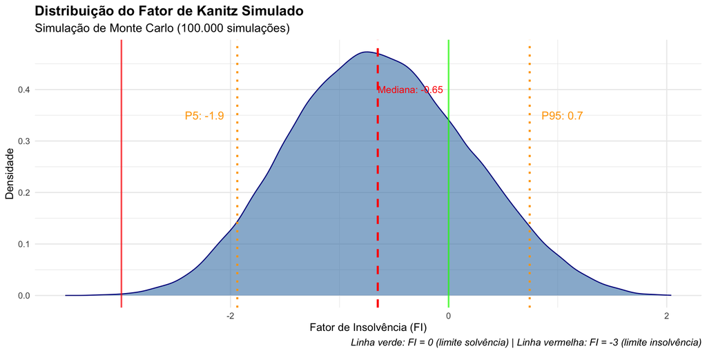

## Sumário dos Resultados

**Método Determinístico vs. Simulação de Monte Carlo**

**Resultados Comparativos:**

[output not shown]

**Distribuição de Risco Simulada:**

**Nota:** P5 e P95 representam os percentis 5% e 95% da distribuição empírica (90% dos cenários ficam neste intervalo)

**Vantagens da Simulação de Monte Carlo:**

**Relevância para Análises Complexas:**

A simulação torna-se ainda mais útil ao considerar:

- **Múltiplos indicadores** com correlações setoriais
- **Cenários macroeconômicos** e sazonalidade
- **Portfólios de crédito** com dependências entre empresas

**💡 Conclusão:**

Monte Carlo transforma uma análise determinística em uma **avaliação probabilística de risco**.

## Análise de Viabilidade sob Incerteza

**Simulação do VPL**

Vamos simular o VPL de um projeto de investimento usando:

$$\text{VPL} = \sum_{t=1}^{\text{tempo}} \frac{\text{receita}_t}{(1 + \text{taxa})^t} + \frac{\text{valor residual}}{(1 + \text{taxa})^{\text{t}}} - \text{investimento inicial}$$

O código R para simular o VPL de um projeto de investimento é exibido nos próximos slides.

## Função `sapply()` — Simulação de Projetos

**Por que usamos `sapply()`?**

Imagine que temos **100 mil projetos diferentes** para simular, e cada projeto:

- Tem **duração própria** (ex: 9, 10, ou 11 anos)
- Receitas e taxas **diferentes a cada simulação**
- Logo, **não é possível vetorizar** os cálculos como em um Excel
- Precisamos de um jeito **elegante e eficiente** de aplicar uma função a **cada simulação individualmente**.
- Função `sapply()`:

```r
vpl_sim <- sapply(1:n_sim, function(i) {
  receitas <- runif(tempo[i], 12000, 16000)
  vpl_fluxos <- sum(receitas / (1 + taxa[i])^(1:tempo[i]))
  vpl_fluxos + residual[i]/(1 + taxa[i])^tempo[i] - invest_rec[i]
})
```

- O que está acontecendo?

| Etapa | O que faz | Analogia |
| --- | --- | --- |
| `1:n_sim` | Vetor [1, 2, …, 100000] | “Fila de projetos a serem analisados” |
| `function(i) {...}` | Função para calcular VPL do projeto `i` | “Receita de como calcular o VPL de um projeto” |
| `sapply(...)` | Aplica a função a cada `i` e devolve vetor de resultados | “Esteira automática de cálculo de VPL” |

- Analogia

> Imagine uma linha de montagem com 100.000 **kits de projeto**. `sapply()` é como uma **máquina que pega cada kit**, aplica a mesma receita de cálculo, e devolve o resultado final.
- Por que **não usamos `for`**?

| `for` loop tradicional | `sapply()` |
| --- | --- |
| Verboso | Mais compacto |
| Exige criar vetor vazio | Retorna vetor pronto |
| Propenso a erros de índice | Mais seguro |

**Resumo:** `sapply()` é como um “for melhorado” que aplica uma função a cada item de uma sequência, devolvendo um vetor com os resultados.

## VPL Determinístico vs. Simulação - Cenário Base

**Cálculo Determinístico com Parâmetros Modais**

**Parâmetros do Projeto (Valores Mais Prováveis):**

- **Investimento inicial**: R$ 75.000 (ponto médio: 65.000 - 85.000)
- **Receitas anuais**: R$ 14.000 (ponto médio: 12.000 - 16.000)
- **Duração**: 10 anos (valor modal da triangular: 9 - 11 anos)
- **Taxa de desconto**: 13% a.a. (valor modal da triangular: 10% - 15%)
- **Valor residual**: R$ 5.000 (valor modal da triangular: 4.000 - 6.000)

**Cálculo do VPL Determinístico:**

```r
# Parâmetros determinísticos (valores modais)
investimento_det <- 75000
receita_anual_det <- 14000
duracao_det <- 10
taxa_desconto_det <- 0.13
valor_residual_det <- 5000

# Cálculo do VPL usando a fórmula padrão
# VPL = ∑[Receitas/(1+r)^t] + Valor_Residual/(1+r)^n - Investimento_Inicial

# Fluxos de receitas descontados
vpl_receitas_det <- sum(receita_anual_det / (1 + taxa_desconto_det)^(1:duracao_det))

# Valor residual descontado
vpl_residual_det <- valor_residual_det / (1 + taxa_desconto_det)^duracao_det

# VPL final
vpl_deterministico <- vpl_receitas_det + vpl_residual_det - investimento_det

# Resultados com formatação brasileira
cat("VPL das receitas:", format(round(vpl_receitas_det, 0), big.mark = ".", decimal.mark = ","), "reais\n")
```

```
VPL das receitas: 75.967 reais
```

```r
cat("VPL do valor residual:", format(round(vpl_residual_det, 0), big.mark = ".", decimal.mark = ","), "reais\n")
```

```
VPL do valor residual: 1.473 reais
```

```r
cat("VPL total (determinístico):", format(round(vpl_deterministico, 0), big.mark = ".", decimal.mark = ","), "reais\n")
```

```
VPL total (determinístico): 2.440 reais
```

```r
# Decisão baseada no VPL determinístico
if (vpl_deterministico > 0) {
  cat("Decisão: Projeto VIÁVEL (VPL > 0)\n")
} else {
  cat("Decisão: Projeto INVIÁVEL (VPL ≤ 0)\n")
}
```

```
Decisão: Projeto VIÁVEL (VPL > 0)
```

**Limitações da Análise Determinística:**

⚠️ **Ignora incerteza**: Usa apenas valores pontuais, sem considerar variabilidade

⚠️ **Decisão binária**: Resultado único não quantifica probabilidade de erro

⚠️ **Subestima risco**: Não mostra amplitude de cenários possíveis

⚠️ **Informação limitada**: Não informa sobre distribuição de resultados

**💡 Próximo Passo:**

A **Simulação de Monte Carlo** captura toda essa incerteza, fornecendo uma **avaliação probabilística completa** do risco do projeto.

## Análise de Viabilidade sob Incerteza

**Simulação de VPL - Código Comentado Detalhadamente**

```r
# Configuração inicial para reprodutibilidade
set.seed(567)
n_sim <- 100000  # 100 mil simulações

# PASSO 1: Simula as variáveis/inputs do VPL
invest_rec <- runif(n_sim, 65000, 85000)    # Investimento inicial (uniforme)
residual   <- rtri(n_sim, 4000, 6000, 5000)   # Valor residual (triangular)
tempo      <- round(rtri(n_sim, 9, 11, 10))   # Duração em anos (triangular)
taxa       <- rtri(n_sim, 0.10, 0.15, 0.13)  # Taxa de desconto (triangular)

# PASSO 2: simula as receitas e calcula VPL
vpl_sim <- sapply(seq_len(n_sim), function(i) {

  # Gera receitas aleatórias para o projeto i
  receitas <- runif(tempo[i], 12000, 16000)

  # Calcula VPL dos fluxos de receitas descontados
  vpl_fluxos <- sum(receitas / (1 + taxa[i])^(1:tempo[i]))

  # VPL total = fluxos + valor residual - investimento inicial
  vpl_total <- vpl_fluxos + residual[i]/(1 + taxa[i])^tempo[i] - invest_rec[i]

  return(vpl_total)  # retorna VPL do projeto i
})


# VPL simulado mediano
vpl_mediano <- median(vpl_sim)  # Mediana dos VPLs simulados
vpl_mediano
```

```
[1] 3524.3
```

```r
# Estimativa da Probabilidade de Viabilidade
prob_viavel <- mean(vpl_sim > 0) * 100  # % de projetos com VPL > 0
prob_viavel
```

```
[1] 66.995
```

```r
# Estimativa da Probabilidade de Inviabilidade
prob_inviavel <- mean(vpl_sim <= 0) * 100  # % de projetos com VPL ≤ 0
prob_inviavel
```

```
[1] 33.005
```

**Por que esse código é assim?**

- **Linha 5-9**: Cada projeto tem características **fixas** (duração, taxa, etc.)
- **Linha 12**: `sapply()` processa cada projeto **individualmente**
- **Linha 15**: Receitas são **diferentes para cada projeto** (tamanho varia com `tempo[i]`)
- **Linha 18**: Fórmula padrão do VPL aplicada ao projeto `i`

**Resultado**: Vetor `vpl_sim` com 100.000 VPLs simulados prontos para análise!

## Distribuição do VPL Simulado

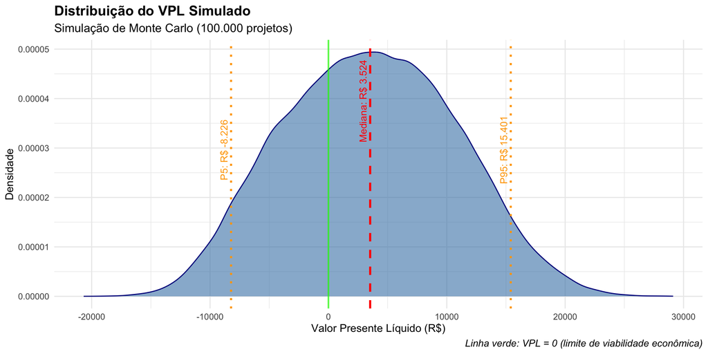

## Resultados

**Análose Determinística vs. Simulação de MC**

**Resultados Comparativos:**

| Métrica | Determinístico | Monte Carlo |
| --- | --- | --- |
| **VPL** | R$ 2.440 | Mediana: R$ 3.524 |
| **Incerteza** | Valor único | P5: R$ -8.226 \| P95: R$ 15.401 |
| **Decisão** | Viável (binária) | Distribuição probabilística |

**Distribuição de Risco Simulada:**

- **P(Viável, VPL > 0)**: 67% → Probabilidade de sucesso do projeto
- **P(Inviável, VPL ≤ 0)**: 33% → Risco de prejuízo financeiro

**Nota:** P5 e P95 representam os percentis 5% e 95% da distribuição empírica (90% dos cenários ficam neste intervalo)

**Vantagens da Simulação de Monte Carlo:**

✅ **Quantifica risco de insucesso**: 33% de chance de VPL negativo vs. decisão binária

✅ **Revela amplitude de cenários**: 90% dos resultados entre R$ -8.226 e R$ 15.401

✅ **Informa decisões**: Quantifica a incerteza / risco do projeto

**Relevância para Análises Complexas:**

A simulação torna-se ainda mais valiosa ao considerar:

- **Correlações entre variáveis** (inflação × juros, receita × custos)
- **Cenários macroeconômicos** e ciclos econômicos
- **Portfólios de projetos** com dependências e restrições orçamentárias

**💡 Conclusão:**

Monte Carlo transforma uma análise determinística em uma **avaliação probabilística de viabilidade**

## Aplicação: Gestão de Capital de Giro no Agronegócio

**Contexto**

**Importância Econômica:**

- Agronegócio representa **parcela significativa do PIB brasileiro**
- Soja: uma das principais commodities de exportação
- Produção com **características sazonais**: descasamento temporal entre custos e receitas

**Características do Ciclo Financeiro:**

- **Desembolsos concentrados**: período de plantio (insumos, maquinário)
- **Receitas concentradas**: período de colheita e comercialização
- **Déficit de caixa temporário**: meses entre investimento e retorno

**Principais Incertezas:**

- **Produtividade**: fatores climáticos, fitossanitários, qualidade do solo
- **Preços**: volatilidade dos mercados internacionais de commodities
- **Custos de insumos**: fertilizantes, defensivos, combustível
- **Taxa de câmbio**: impacta custos (importações) e receitas (exportações)

**Problema Gerencial:**

Qual o **capital de giro necessário** para atravessar o ciclo produtivo sem comprometer a operação?

**Relevância da Simulação:**

- Métodos determinísticos podem **subestimar** necessidades de capital
- Monte Carlo permite capturar **interações entre múltiplas variáveis incertas**
- Possibilita **quantificar probabilidades** de diferentes cenários

**Nota**: Os parâmetros utilizados neste exemplo são **ilustrativos** para fins didáticos apenas.

## Modelagem: Fluxo de Caixa da Safra de Soja

**Estrutura do Exemplo**

**Fazenda Hipotética:**

- **Área**: 2.000 hectares
- **Ciclo**: Janeiro (plantio) → Outubro (colheita/venda)
- **Custo total**: R$ 4.000/hectare

**Cronograma de Desembolsos (% do custo total - exemplo típico):**

| Mês | Jan | Fev | Mar | Abr | Mai | Jun | Jul | Ago | Set | Out |
| --- | --- | --- | --- | --- | --- | --- | --- | --- | --- | --- |
| % Custo | 10% | 25% | 20% | 10% | 5% | 5% | 5% | 5% | 5% | 10% |

**Nota**: Os 10% em outubro representam custos de colheita, transporte e comercialização.

**Receitas:**

- **Venda antecipada** (janeiro): 30% da produção a preço forward (desconto 5%)
- **Venda spot** (outubro): 70% da produção restante

**Parâmetros Incertos (para fins didáticos):**

| Variável | Mínimo | Moda | Máximo | Unidade |
| --- | --- | --- | --- | --- |
| **Produtividade** | 45 | 60 | 75 | sacas/ha |
| **Preço spot** | 70 | 85 | 100 | R$/saca |
| **Custo/hectare** | 3.500 | 4.000 | 4.500 | R$/ha |

**Correlação Assumida:**

- Produtividade × Preço: -0.30 (hipótese: anos de baixa produção → preços mais altos)

**Objetivo da Simulação:**

Estimar a **distribuição do Déficit Máximo (Necessidade de Capital de Giro)**

$$\text{Déficit máximo} = -\min_t\bigl(\mathrm{SA}_t\bigr)$$

➜ *Simulação de Monte Carlo (MC)*

• 20 000 cenários de **produtividade, preço** (correlação –0,30) e **custo**  
• Resultado: **curva de probabilidade** da necessidade de caixa ao longo do ciclo

**Metodologia:**

- A metodologia de simulação segue as diretrizes de Hardaker *et al.* (2004) para gestão de risco agrícola e implementa os procedimentos de Richardson, Klose e Gray (2000) para simulação Monte Carlo no agronegócio.

**⚠️ Importante**: Todos os parâmetros são **ilustrativos**. Em aplicações reais, devem ser calibrados com dados históricos específicos da região e cultura.

## Conceitos Fundamentais: Fluxo de Caixa Acumulado

**Entendendo o “Déficit Máximo” e sua Importância**

**O que é o Fluxo de Caixa Acumulado?**

- **Mês a mês**: Receitas - Custos = Fluxo líquido mensal
- **Acumulado**: Soma progressiva dos fluxos mensais desde janeiro
- **Exemplo**: Se jan = -100, fev = -50, mar = +200 → Acumulados: -100, -150, +50

**Por que o Déficit Máximo é Importante?**

✅ **Déficit máximo = MAIOR necessidade de caixa** durante o ciclo

✅ **Representa quanto de capital de giro** a fazenda precisa ter disponível

✅ **Exemplo prático**: Se déficit máximo = R$ 2 milhões, a fazenda precisa de R$ 2 milhões de capital de giro

**Interpretação Gerencial:**

| Déficit Máximo | Significado | Ação Necessária |
| --- | --- | --- |
| **R$ 500 mil** | Necessidade máxima de R$ 500 mil | Linha de crédito de R$ 500 mil |
| **R$ 2 milhões** | Necessidade máxima de R$ 2 milhões | Capital de giro de R$ 2 milhões |
| **R$ 0** | Sempre positivo | Não precisa de financiamento |

**💡 Insight Principal:**

O **déficit máximo** identifica o **pior momento financeiro** do ciclo produtivo - exatamente quando mais precisamos de capital de giro!

**Por que Simulamos?**

Esse valor varia conforme produtividade, preços e custos. A simulação mostra **toda a distribuição** de necessidades possíveis, não apenas um valor pontual.

## Conceitos Fundamentais: NCG

**Definição**

Chamamos de **Necessidade de Capital de Giro (NCG)** o montante máximo de recursos financeiros que a empresa precisa ter disponível para atravessar todo o ciclo produtivo sem interromper suas operações.

Seja

$$\text{SA}_t = \sum_{k=1}^{t} (\text{Receitas}_k - \text{Custos}_k)$$

o **Saldo de Caixa Acumulado** até o mês $t$, obtido somando‐se todos os fluxos líquidos mensais desde o início do ciclo.

A NCG é então definida por

$$\begin{aligned}
\text{NCG} &= -\min_{t}\bigl(\text{SA}_t\bigr) \\[6pt]
&= \text{Déficit máximo}
\end{aligned}$$

isto é, o **valor absoluto do menor (mais negativo) saldo acumulado** ao longo de todo o período analisado. $\text{NCG} = \text{Déficit máximo}$

- Quando $\text{SA}_t$ atinge seu ponto mais baixo, temos o **déficit máximo**.
- Financiar exatamente esse déficit garante que a empresa consiga pagar todas as contas até que as receitas da colheita (ou das vendas) entrem no caixa.

**Intuição:** pense no saldo acumulado como o nível de água de uma caixa d’água — ele desce conforme você paga insumos e sobe quando recebe pelas vendas. A NCG é a profundidade máxima. Disponibilizar esse volume de recursos (via reservas ou linha de crédito) evita que o nível fique “abaixo de zero” e a operação “seque”.

## Funções `lapply()` + `do.call()`

**Por que usaR `lapply()` + `do.call(rbind, ...)`?**

Precisamos simular **20 mil safras** e obter um **data frame único** com os resultados

Cada simulação (`simula_safra()`) retorna um **data frame de 1 linha** com:

- Déficit máximo
- Lucro final
- Produtividade
- Preço final
- **Passo 1:** Usamos `lapply()` para **repetir a função**

```r
lista_resultados <- lapply(1:n_sim, function(x) simula_safra())
```

| Função | O que faz | Analogia |
| --- | --- | --- |
| `1:n_sim` | Vetor de números 1 a 20000 | Lista de IDs das safras |
| `function(x) simula_safra()` | Aplica a simulação a cada ID | Receita para simular uma safra |
| `lapply(...)` | Executa para cada safra e **guarda numa lista** | Caixa com 20.000 recibos (um por safra) |

- **Passo 2:** Usamos `do.call(rbind, ...)` para **juntar tudo**

```r
resultados <- do.call(rbind, lista_resultados)
```

| Função | O que faz | Analogia |
| --- | --- | --- |
| `do.call()` | Executa uma função (`rbind`) em **todos os elementos da lista** | Um robô que **empilha os 20.000 recibos** numa planilha única |
| `rbind(df1, df2, ..., df20000)` | Junta todos os data frames | Linhas de uma planilha final |

- Tudo junto:

```r
resultados <- do.call(rbind, lapply(1:n_sim, function(x) simula_safra()))
```

- Analogia

> Você tem 20.000 **envelopes** (cada um com um relatório de safra). `lapply()` preenche os envelopes. `do.call(rbind, ...)` abre todos e cola numa única **planilha** com os 20.000 resultados.

Por que não usar `sapply()`?

- `sapply()` tenta devolver **vetores** — bom para números
- Aqui cada item é um **data frame** → melhor usar `lapply()`, que devolve **lista**
- Por que não usar `for`?

`for` exige criar um data frame vazio e juntar resultados um a um (ineficiente e suscetível a erros)

**Resumo:** `lapply()` + `do.call(rbind, ...)` é a forma mais elegante de simular milhares de cenários complexos e consolidar os resultados.

## Simulação de Monte Carlo: Código R

**Implementação da Simulação**

```r
# Parâmetros da fazenda hipotética
set.seed(123)
area_ha <- 2000
n_sim <- 20000

# Cronograma de desembolsos (% do custo total por mês)
cronograma_custos <- c(0.10, 0.25, 0.20, 0.10, 0.05, 0.05, 0.05, 0.05, 0.05, 0.10)

# Parâmetros de comercialização
venda_antecipada <- 0.30 # 30% vendido antecipadamente
desconto_forward <- 0.95 # preço forward = 95% do spot

# Função para simular um cenário
simula_safra <- function() {
  # Simula parâmetros incertos (distribuições triangulares)
  produtividade <- rtri(1, 45, 75, 60) # sacas/ha
  custo_ha <- rtri(1, 3500, 4500, 4000) # R$/ha

  # Gerar preço base
  preco_base <- rtri(1, 70, 100, 85) # R$/saca

  # Aplicar correlação negativa de -0.30 entre produtividade e preço
  # Normalizar produtividade em torno da média
  prod_media <- 60
  prod_desvio <- 15 # (75-45)/2
  prod_padronizada <- (produtividade - prod_media) / prod_desvio

  # Ajustar preço baseado na correlação
  preco_desvio <- 15 # (100-70)/2
  ajuste_correlacao <- -0.30 * prod_padronizada * preco_desvio
  preco_spot <- preco_base + ajuste_correlacao

  # Garantir que o preço permaneça dentro dos limites
  preco_spot <- pmax(70, pmin(100, preco_spot))

  # Calcula fluxos mensais
  custos_mensais <- cronograma_custos * custo_ha * area_ha

  # Receitas (concentradas em janeiro e outubro)
  receitas <- rep(0, 10)
  receitas[1] <- venda_antecipada * produtividade * area_ha * preco_spot * desconto_forward
  receitas[10] <- (1 - venda_antecipada) * produtividade * area_ha * preco_spot

  # Fluxo de caixa acumulado
  fluxo_liquido <- receitas - custos_mensais
  saldo_acumulado <- cumsum(fluxo_liquido)

  # Retorna métricas de interesse
  data.frame(
    deficit_maximo = -min(saldo_acumulado), # maior déficit no período (sempre positivo)
    lucro_final = saldo_acumulado[10],      # resultado final
    produtividade = produtividade,
    preco_final = preco_spot
  )
}

# Executa simulação Monte Carlo
resultados <- do.call(rbind, lapply(1:n_sim, function(x) simula_safra()))

# Verificar correlação obtida
correlacao_simulada <- cor(resultados$produtividade, resultados$preco_final)
cat("Correlação obtida:", round(correlacao_simulada, 3), "(alvo: -0.30)\n")
```

```
Correlação obtida: -0.279 (alvo: -0.30)
```

```r
# Exibe resumo básico como data frame
resumo_basico <- data.frame(
  Métrica = c("Déficit máximo médio", "Maior déficit simulado", "Lucro médio esperado"),
  Valor_Mil_Reais = c(
    round(mean(resultados$deficit_maximo) / 1000),
    round(max(resultados$deficit_maximo) / 1000),
    round(mean(resultados$lucro_final) / 1000)
  )
)
print(resumo_basico)
```

```
                 Métrica Valor_Mil_Reais
1   Déficit máximo médio            4301
2 Maior déficit simulado            6070
3   Lucro médio esperado            2017
```

## Nota sobre a Implementação da Correlação

**Solução Aproximada**

**Atenção**: O método usado para introduzir correlação entre produtividade e preço é uma **aproximação simplificada** adequada para fins didáticos.

💡 **Lembre-se**: Em ciência de dados/estatística, frequentemente começamos com soluções simples e evoluímos para métodos mais sofisticados conforme necessário.

## Resultados da Simulação: Necessidade de Capital de Giro

**Análise dos Resultados**

```r
# A variável deficit_maximo já está em valores positivos (em reais)
# Converte para milhões para facilitar a leitura
necessidade_capital <- resultados$deficit_maximo / 1000000  # em milhões

# ========================================
# VALIDAÇÃO DO MODELO
# ========================================
correlacao_simulada <- cor(resultados$produtividade, resultados$preco_final)
cat("Correlação obtida entre produtividade e preço:",
    round(correlacao_simulada, 3), "\n")
```

```
Correlação obtida entre produtividade e preço: -0.279
```

```r
# ========================================
# ESTATÍSTICAS DESCRITIVAS
# ========================================
estatisticas_basicas <- data.frame(
  Métrica = c("Necessidade média", "Necessidade máxima", "Desvio-padrão"),
  Valor_Milhoes_R = c(
    round(mean(necessidade_capital), 1),
    round(max(necessidade_capital), 1),
    round(sd(necessidade_capital), 1)
  )
)

# Exibe as estatísticas básicas
estatisticas_basicas
```

```
             Métrica Valor_Milhoes_R
1  Necessidade média             4.3
2 Necessidade máxima             6.1
3      Desvio-padrão             0.5
```

```r
# ========================================
# PERCENTIS PARA PLANEJAMENTO
# ========================================
percentis <- quantile(necessidade_capital, probs = c(0.50, 0.75, 0.90, 0.95))
tabela_percentis <- data.frame(
  Percentil = c("50%", "75%", "90%", "95%"),
  Cenarios_Cobertos = c("50% dos cenários", "75% dos cenários",
                        "90% dos cenários", "95% dos cenários"),
  Necessidade_Milhoes_R = round(percentis, 1)
)

# Exibe a tabela de percentis
tabela_percentis
```

```
    Percentil Cenarios_Cobertos Necessidade_Milhoes_R
50%       50%  50% dos cenários                   4.3
75%       75%  75% dos cenários                   4.6
90%       90%  90% dos cenários                   4.9
95%       95%  95% dos cenários                   5.1
```

```r
# ========================================
# PROBABILIDADES
# ========================================
probabilidades_risco <- data.frame(
  Limite_Milhoes_R = c(1, 2, 3),
  Probabilidade_Exceder_Pct = c(
    round(mean(necessidade_capital > 1) * 100, 1),
    round(mean(necessidade_capital > 2) * 100, 1),
    round(mean(necessidade_capital > 3) * 100, 1)
  )
)

# Exibe as probabilidades de exceder limites
probabilidades_risco
```

```
  Limite_Milhoes_R Probabilidade_Exceder_Pct
1                1                     100.0
2                2                     100.0
3                3                      99.7
```

**Visualização da Distribuição:**

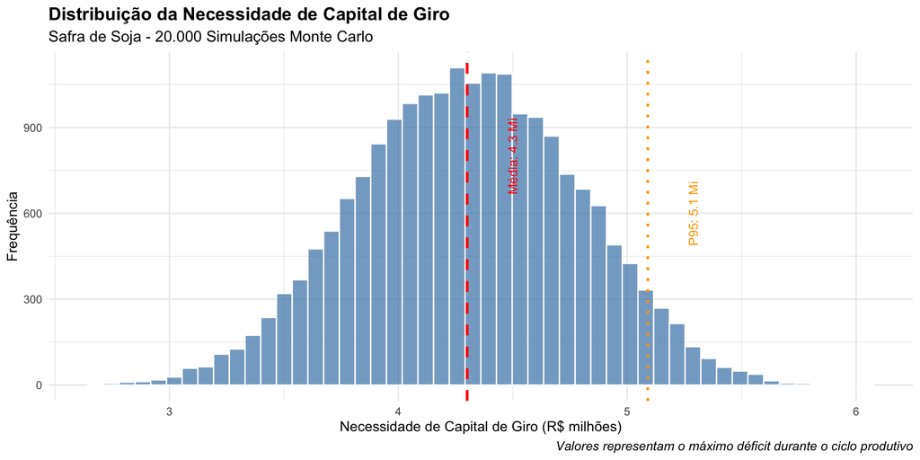

**💡 Interpretação para Administradores:**

## Decisões Estratégicas Baseadas na Simulação

**Aplicações Práticas dos Resultados**

```
              Cenario          Descrição Necessidade_Milhoes_R
1        Cenário Base  Necessidade média                   4.3
2 Cenário Conservador      Percentil 95%                   5.1
3      Cenário Stress Pior caso simulado                   6.1
          Uso_Recomendado
1       Orçamento inicial
2        Linha de crédito
3 Reserva de contingência
```

**Vantagem da Simulação sobre Análise Determinística:**

Monte Carlo revela a **distribuição completa** de necessidades de capital, permitindo:

- **Quantificar probabilidades** de diferentes cenários
- **Otimizar estratégias** de financiamento
- **Preparar contingências** para situações extremas
- **Tomar decisões informadas** baseadas em risco quantificado

## Extensões e Aplicações Avançadas

**Possíveis Refinamentos do Modelo**

**🌱 Aprimoramentos Realísticos:**

**Risco Climático:**

- Incluir eventos extremos (seca, geada) com distribuições específicas
- Modelar correlação espacial entre regiões produtoras

**Dinâmica de Preços:**

- Incorporar sazonalidade e tendências de preços
- Considerar volatilidade condicional (modelos GARCH)

**Aspectos Financeiros:**

- Incluir custo do capital sobre déficits
- Modelar diferentes modalidades de crédito rural
- Considerar impostos e taxas sobre operações

**📊 Análises Complementares:**

**Análise de Sensibilidade:**

- Identificar quais parâmetros mais impactam a necessidade de capital
- Determinar os **fatores críticos** de risco financeiro

**Otimização de Estratégias:**

- Percentual ótimo de venda antecipada
- Timing ideal para contratação de hedge
- Dimensionamento ótimo de reservas de liquidez

**Validação do Modelo:**

- Backtesting com dados históricos disponíveis
- Comparação com benchmarks setoriais

**🎯 Valor para a Tomada de Decisão:**

1. **Quantifica** necessidades de capital com base probabilística
2. **Identifica** os principais direcionadores de risco
3. **Permite** simulação de diferentes estratégias de mitigação
4. **Fundamenta** negociações financeiras com dados objetivos

**Resultado**: Transforma a gestão financeira agrícola de decisões **intuitivas** para escolhas **baseadas em análise quantitativa de risco**.

## Erro de Monte Carlo

**Precisão da Estimativa**

- A **margem de erro** em Monte Carlo decresce com $\sqrt{n}$:

$$\text{EP} \approx \frac{\sigma}{\sqrt{n}}.$$

- Para probabilidade $p = P(VPL>0)$, o erro padrão é:

$$SE(p) = \sqrt{\frac{p(1-p)}{n}}.$$

**Exemplo Prático**:

Se $P(VPL > 0) = 0.75$ com $n = 10.000$ simulações:

```r
p_estimado <- 0.75
n_simulacoes <- 10000
erro_padrao <- sqrt(p_estimado * (1 - p_estimado) / n_simulacoes)
erro_padrao  # ≈ 0.0043
```

```
[1] 0.0043301
```

```r
# Intervalo de confiança aproximado (95%)
ic_inferior <- p_estimado - 1.96 * erro_padrao  # ≈ 0.741
ic_superior <- p_estimado + 1.96 * erro_padrao  # ≈ 0.759
```

**Interpretação**: A probabilidade verdadeira está entre 74.1% e 75.9% com 95% de confiança.

**Regras Práticas**:

- **Duplicar $n$** reduz o erro em $\approx 1/\sqrt{2} \approx 0.71$ (melhora de 29%)
- **Quadruplicar $n$** reduz o erro pela metade
- Para **erro < 1%** em probabilidades: use $n \geq 10.000$
- Para **erro < 0.1%** em probabilidades: use $n \geq 1.000.000$

**Importância**: Garanta $n$ suficientemente grande para decisões confiáveis, especialmente em contextos financeiros críticos.

## Limitações e Cuidados com Monte Carlo

**Quando Monte Carlo Pode Falhar**

**⚠️ Principais Limitações:**

**1. Garbage In, Garbage Out**

- Qualidade dos resultados = qualidade dos inputs
- Distribuições mal especificadas geram conclusões errôneas
- Exemplo: assumir normalidade para variáveis que não podem ser negativas

**2. Correlações Ignoradas**

- Tratar variáveis independentes quando são correlacionadas
- Exemplo: inflação e taxa de juros geralmente se movem juntas

**3. Excesso de Confiança**

- Resultados podem parecer mais precisos do que realmente são
- “Pseudo-precisão”: 6 casas decimais em estimativas baseadas em opiniões

**4. Complexidade Desnecessária**

- Usar simulação quando análise simples seria suficiente
- Exemplo: VPL com apenas 1 parâmetro incerto

**🎯 Boas Práticas:**

✅ **Valide** as distribuições escolhidas com dados ou especialistas

✅ **Teste** a sensibilidade dos resultados aos parâmetros

✅ **Compare** com métodos mais simples quando possível

✅ **Documente** todas as suposições claramente

✅ **Comunique** a incerteza inerente às estimativas

**Lembre-se**: Monte Carlo é uma ferramenta poderosa, mas não substitui o **julgamento crítico** sobre as suposições do modelo.

## Simulação de Monte Carlo

**Relevância para o Mestrado**

**Na pesquisa**

- **Dissertações**: tópico recorrente em finanças quantitativas
- **Periódicos internacionais**: metodologia amplamente aceita

**Na carreira**

- **Diferencial competitivo**: poucos dominam simulação em Python/R
- **Tomada de decisão**: quantificar risco → decisões baseadas em dados
- **Compliance**: exigências de Basileia, CVM, BACEN (setor financeiro)

**🚀 Competências-chave**

1. **Desenvolver pensamento probabilístico** (vs. determinístico)
2. **Modelar quantitativamente** problemas complexos
3. **Comunicar risco** de forma clara a stakeholders não-técnicos

> **Resultado:** capacidade de apoiar decisões estratégicas sob incerteza – habilidade **altamente valorizada** no mercado.

## Exercício 1

**Simulação do Índice de Liquidez Rápida**

O **Índice de Liquidez Rápida (ILR)** mede a capacidade de uma empresa pagar suas obrigações de curto prazo sem depender da venda de estoques:

$$\text{ILR} = \frac{\text{Ativo Circulante} - \text{Estoques}}{\text{Passivo Circulante}}$$

**Cenário**: Você é analista financeiro de uma empresa do setor de varejo e precisa avaliar o risco de liquidez sob incerteza.

**Informações dos especialistas** (baseadas em dados setoriais):

- **Ativo Circulante**: entre R$ 800 mil e R$ 1.200 mil (mais provável: R$ 950 mil)
- **Estoques**: entre R$ 200 mil e R$ 400 mil (mais provável: R$ 280 mil)
- **Passivo Circulante**: entre R$ 600 mil e R$ 900 mil (mais provável: R$ 720 mil)

**Suas tarefas**:

1. **Simule 20.000 cenários** do ILR usando Monte Carlo com distribuições triangulares
2. **Calcule $P(\text{ILR} < 1)$** e interprete o resultado
3. **Compare** o ILR médio simulado com o modelo determinístico (valores mais prováveis)
4. **Recomende ações** se a probabilidade de ILR < 1 for maior que 40%

**Código estrutura** (complete o código):

```r
# fixa a semente para reprodutibilidade
set.seed(2024)

# Define o número de simulações
n_sim <- 20000

# Complete os parâmetros (min, max, moda)
ativo_circ <- rtri(n_sim, ___, ___, ___)
estoques   <- rtri(n_sim, ___, ___, ___)
passivo_circ <- rtri(n_sim, ___, ___, ___)

# Calcule o ILR
ilr_sim <- (ativo_circ - estoques) / passivo_circ

# Complete as análises
prob_ilr_baixo <- mean(ilr_sim < 1) * 100
ilr_medio <- mean(ilr_sim)

# Modelo determinístico para comparação
ilr_deterministico <- (950 - 280) / 720

# Exiba os resultados
cat("Probabilidade ILR < 1:", round(prob_ilr_baixo, 1), "%\n")
cat("ILR médio simulado:", round(ilr_medio, 2), "\n")
cat("ILR determinístico:", round(ilr_deterministico, 2), "\n")
```

**Perguntas**:

1. Qual a probabilidade de ILR < 1? Como interpreta esse risco?
2. Por que o ILR médio simulado é próximo ao determinístico?
3. Que ações recomendaria se P(ILR < 1) > 40%?

## Exercício 1

**Soluções**

Código R completo:

```r
# define os parâmetros necessários
set.seed(2024)
n_sim <- 20000

# Parâmetros das distribuições triangulares (min, max, moda) - em milhares de R$
ativo_circ <- rtri(n_sim, 800, 1200, 950)    # Ativo Circulante
estoques <- rtri(n_sim, 200, 400, 280)       # Estoques
passivo_circ <- rtri(n_sim, 600, 900, 720)   # Passivo Circulante

# Cálculo do ILR para cada cenário
ilr_sim <- (ativo_circ - estoques) / passivo_circ

# Probabilidade de ILR < 1 (em %)
prob_risco <- mean(ilr_sim < 1) * 100

# ILR médio simulado
ilr_medio <- mean(ilr_sim)

# Desvio-padrão (opcional)
ilr_desvio <- sd(ilr_sim)

# Modelo determinístico (valores mais prováveis)
ilr_det <- (950 - 280) / 720    # Resultado: 0.930

# Exibição dos resultados
cat("=== RESULTADOS DA SIMULAÇÃO ===\n")
```

```
=== RESULTADOS DA SIMULAÇÃO ===
```

```r
cat("Probabilidade de ILR < 1:", round(prob_risco, 1), "%\n")
```

```
Probabilidade de ILR < 1: 67.4 %
```

```r
cat("ILR médio simulado:", round(ilr_medio, 3), "\n")
```

```
ILR médio simulado: 0.938
```

```r
cat("ILR determinístico:", round(ilr_det, 3), "\n")
```

```
ILR determinístico: 0.931
```

```r
cat("Desvio-padrão do ILR:", round(ilr_desvio, 3), "\n")
```

```
Desvio-padrão do ILR: 0.149
```

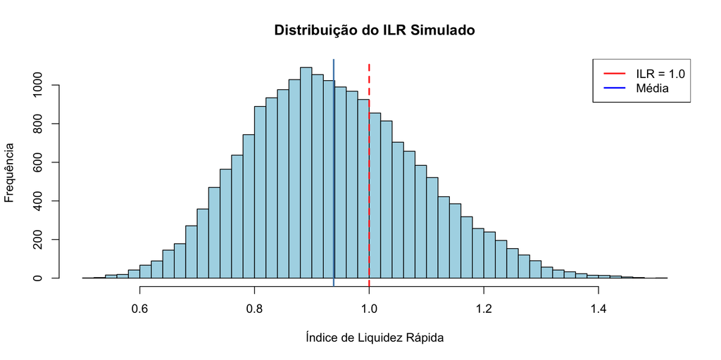

```r
# Visualização opcional
hist(ilr_sim, breaks = 50, col = "lightblue",
     main = "Distribuição do ILR Simulado",
     xlab = "Índice de Liquidez Rápida", ylab = "Frequência")
abline(v = 1, col = "red", lwd = 2, lty = 2)  # Linha crítica
abline(v = ilr_medio, col = "steelblue", lwd = 2)  # Média
legend("topright", c("ILR = 1.0", "Média"), col = c("red", "blue"), lwd = 2)
```

- **2. Por que o ILR médio simulado é próximo ao determinístico?**

**Resposta:** Pela **Lei dos Grandes Números**, a média de muitas simulações (20.000) converge para o valor esperado teórico. Por isso, o ILR médio simulado (0.939) fica muito próximo do cálculo determinístico (0.930).

- **3. Que ações recomendaria se P(ILR < 1) > 40%?**

**Monitoramento:**

- Acompanhar ILR mensalmente
- Estabelecer alertas quando ILR < 0.85
- Monitorar tendências sazonais

**Gestão de Capital de Giro:**

- Acelerar cobrança de clientes (reduzir prazo médio de recebimento)
- Negociar prazos maiores com fornecedores
- Otimizar níveis de estoque (evitar excesso)

**Flexibilidade Financeira:**

- Pré-negociar linha de crédito rotativo
- Diversificar fontes de financiamento de curto prazo
- Manter reserva de caixa para emergências

**Conclusão:** Essas são medidas **preventivas**, não de emergência. Para empresas de varejo, ILR próximo a 1.0 é comum, pois os estoques fazem parte do modelo de negócio.

- Pontos de Aprendizagem:
1. **Monte Carlo** quantifica incerteza que análises determinísticas não capturam
2. **Distribuições triangulares** são úteis quando há estimativas de min/max/moda
3. **Interpretação contextual** é essencial - mesmos números podem ter significados diferentes por setor
4. **Simulação** informa decisões de gestão com base probabilística, não apenas cenários pontuais

# Pacote tidyquant, Séries de Preços e de Retornos de Ações

## Pacote `tidyquant`

**Descrição**

- Com utilizaremos dados reais de séries de preços de ações do para ilustrar o VaR e ES (CVaR), precisamos entender como importar essas séries de preços de ações usando o `tidyquant`.
- O pacote `tidyquant` integra os melhores pacotes da linguagem R para coletar, manipular e analisar dados financeiros com o `tidyverse`.
- Como o tidyquant é possível realizar análises financeiras completas usando a sintaxe do `tidyverse`.
- A função `tq_get()` do pacote `tidyquant` é uma muito útil para coletar dados financeiros de diversas fontes, como Yahoo Finance, FRED, entre outras.

## Função `tq_get()`

**Função `tq_get()`**

- A sintaxe básica da função `tq_get()` é:

```r
tq_get(x, from = NULL, to = NULL, ...)
```

Onde:

- `x`: é um vetor de tickers das ações ou o nome do índice que você deseja obter os dados.
- `from`: é a data de início para a coleta dos dados (formato “YYYY-MM-DD”).
- `to`: é a data de término para a coleta dos dados (formato “YYYY-MM-DD”).

A função retorna um data frame com as colunas:

- `symbol`: é o ticker da ação ou do índice.
- `date`: é a data da observação.
- `open`: é o preço de abertura da ação no dia.
- `high`: é o preço mais alto da ação no dia.
- `low`: é o preço mais baixo da ação no dia.
- `close`: é o preço de fechamento da ação no dia.
- `volume`: é o volume de ações negociadas no dia.

## Exemplo 1 - Função `tq_get()`

**Importação de Séries de Preços Diários de 2 Ações**

```r
# salva as séries importadas no objeto serie_bivariada
serie_bivariada <- c("AAPL", "META") %>%
  # obtem os dados de fechamento das ações a partir de 01/01/2024
  tq_get(from = "2024-01-01") %>%
  # seleciona as colunas relevantes
  select(symbol, date, close) %>%
  # renomeia as colunas para facilitar a leitura
  rename(
    compania = symbol,
    dia = date,
    preco_fechamento = close
  )

# Exibe as 6 primeiras linhas da data frame
head(serie_bivariada)
```

```
# A tibble: 6 × 3
  compania dia        preco_fechamento
  <chr>    <date>                <dbl>
1 AAPL     2024-01-02             186.
2 AAPL     2024-01-03             184.
3 AAPL     2024-01-04             182.
4 AAPL     2024-01-05             181.
5 AAPL     2024-01-08             186.
6 AAPL     2024-01-09             185.
```

```r
# Exibe as 6 últimas linhas da data frame
tail(serie_bivariada)
```

```
# A tibble: 6 × 3
  compania dia        preco_fechamento
  <chr>    <date>                <dbl>
1 META     2025-06-17             697.
2 META     2025-06-18             696.
3 META     2025-06-20             682.
4 META     2025-06-23             699.
5 META     2025-06-24             712.
6 META     2025-06-25             709.
```

## Preparação de Dados: pivot_wider()

**Função pivot_wider() do tidyr - Exercício 3**

A função `pivot_wider()` transforma dados do formato longo para o formato largo (*wide*),.

**Por que precisamos transformar?**

Para estimar a correlação entre as séries de preços de duas ações, precisamos que cada série de preços seja uma coluna separada, com as datas alinhadas, entretanto, a função tq_get() retorna os dados no formato longo, onde cada linha representa um preço de uma ação em uma data específica, ou seja, as séries de preços estão empilhadas verticalmente.

**Formato Longo** (estrutura retornada pela função `tq_get()`):

```r
dados_longo <-
tibble(
  empresa = c("PETR4.SA", "PETR4.SA", "ITUB4.SA", "ITUB4.SA"),
  data = as.Date(c("2024-01-02", "2024-01-03", "2024-01-02", "2024-01-03")),
  preco = c(35.50, 36.20, 28.30, 28.75)
)

dados_longo
```

```
# A tibble: 4 × 3
  empresa  data       preco
  <chr>    <date>     <dbl>
1 PETR4.SA 2024-01-02  35.5
2 PETR4.SA 2024-01-03  36.2
3 ITUB4.SA 2024-01-02  28.3
4 ITUB4.SA 2024-01-03  28.8
```

**Formato Largo**:

```r
dados_wide <-
tibble(
  data = as.Date(c("2024-01-02", "2024-01-03")),
  PETR4.SA = c(35.50, 36.20),
  ITUB4.SA = c(28.30, 28.75)
)

dados_wide
```

```
# A tibble: 2 × 3
  data       PETR4.SA ITUB4.SA
  <date>        <dbl>    <dbl>
1 2024-01-02     35.5     28.3
2 2024-01-03     36.2     28.8
```

**Sintaxe**:

```r
dados_wide <- dados_longo %>%
  pivot_wider(
    names_from = empresa,    # variável que será nomes de colunas
    values_from = preco      # variável com os valores
  )

dados_wide
```

```
# A tibble: 2 × 3
  data       PETR4.SA ITUB4.SA
  <date>        <dbl>    <dbl>
1 2024-01-02     35.5     28.3
2 2024-01-03     36.2     28.8
```

## Exemplo 2 - Função `tq_get()`

**Importação de 3 Séries de Preços Diários de Ações**

```r
serie_precos <- c("PETR4.SA", "MGLU3.SA", "ITUB4.SA") %>%
  # importa as séries de preços as ações: PETR4, MGLU3 e ITUB4
  tq_get(from = "2024-01-01") %>%
  # seleciona as variáveis relevantes
  select(symbol, date, close) %>%
  # converte o formato longo para o formato largo
  pivot_wider(names_from = symbol, values_from = close) %>%
  # renomeia as variáveis
  rename(dia = date,
         petr4 = PETR4.SA,
         mglu3 = MGLU3.SA,
         itub4 = ITUB4.SA)


# exibe as primeiras linhas
head(serie_precos)
```

```
# A tibble: 6 × 4
  dia        petr4 mglu3 itub4
  <date>     <dbl> <dbl> <dbl>
1 2024-01-02  37.8  19.2  30.5
2 2024-01-03  39.0  18.7  30.1
3 2024-01-04  38.6  18.1  29.9
4 2024-01-05  38.7  18.4  30.6
5 2024-01-08  38.4  19.5  30.3
6 2024-01-09  38.1  20.0  30.3
```

## Por que Analisar Retornos e não Preços?

**Vantagens**

- **Propriedades estatísticas mais convenientes**:
  - Retornos tendem a ser mais estacionários (comportamento estatístico estável ao longo do tempo)
- **Tipos de retornos**:
  - **Retorno simples**: $R_t = \frac{P_t - P_{t-1}}{P_{t-1}}$ (interpretação: percentual de ganho)
  - **Retorno logarítmico**: $r_t = \ln\left(\frac{P_t}{P_{t-1}}\right)$ (vantagem matemática: aditividade)
- **Aplicação prática**: Análise de carteiras de investimento e avaliação de desempenho.

## Gráficos: Preços x Retornos - Petrobrás

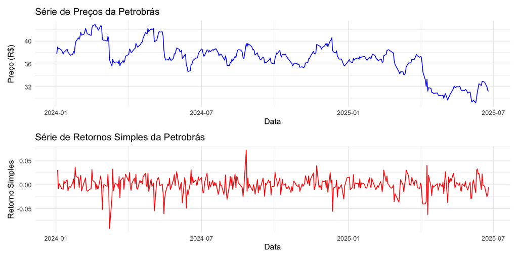

# Aplicação - Valor-em-Risco (VaR)

## Introdução ao Valor-em-Risco (VaR)

**Origem do VaR**

- VaR (*Value-at-Risk*) foi introduzido pelo banco **JP Morgan** em 1994, com a metodologia **RiskMetrics**.
- Objetivo: sintetizar o risco de uma carteira em um único número.
- Motivado pela necessidade de apresentar diariamente, às 16:15, uma medida consolidada de risco.
- Tornou-se uma ferramenta essencial na gestão de riscos e exigência regulatória.

[RiskMetrics (JP Morgan)](https://www.msci.com/documents/10199/5915b101-4206-4ba0-aee2-3449d5c7e95a)

## O Comitê de Basileia e o VaR

**Linha do Tempo**

- **Basileia I (1988):** foco em risco de crédito, exigência de capital mínimo = 8% dos ativos ponderados pelo risco (RWA).
- **Emenda de 1996:** introduz uso do **VaR para risco de mercado**.
- **Basileia II (2004):** três pilares; VaR incluído no Pilar 1 (exigências de capital).

-**Basileia III (2010-2017):** amplia exigências, inclui LCR, NSFR, alavancagem, output floor.

- **FRTB (2019+):** substitui o VaR pelo **Expected Shortfall (ES)**.

## Principais Siglas Regulatórias

**Glossário**

| Sigla | Significado |
| --- | --- |
| **CET1** | Common Equity Tier 1 (capital de alta qualidade) |
| **LCR** | Liquidity Coverage Ratio |
| **NSFR** | Net Stable Funding Ratio |
| **RWA** | Ativos Ponderados pelo Risco |
| **FRTB** | Nova abordagem para risco de mercado |
| **Output Floor** | Capital mínimo ≥ 72,5% do padrão |

## O que é o Valor-em-Risco (VaR)?

**Nota**

- O **VaR (Value-at-Risk)** é uma medida de risco que responde à pergunta:

> “**Qual é a pior perda esperada, com uma pequena probabilidade de ser excedida ($p$)?**”
- O VaR depende de:
  - Um horizonte de tempo (ex: 1 dia, 10 dias);
  - Um **nível de probabilidade** $p$ (ex: 1%);
  - A distribuição de perdas (retornos) da carteira.
- Por exemplo, com $p = 0,01$, o VaR indica a perda que **será excedida em 1% dos dias**, em média.

## Valor-em-Risco (VaR)

**Definição Formal**

- Seja $L/P$ a **variável aleatória de perdas e ganhos** de uma carteira.
- O Valor-em-Risco com nível de probabilidade $p$ é o quantil de ordem $1 - p$ da distribuição de $L/P$:

$$VaR_{(p)} = \inf \left\{ q \in R \mid P(L \leq q) \geq 1 - p \right\}$$
> O VaR com probabilidade $p$ é o menor valor $q$ tal que a probabilidade de a perda ser menor ou igual a $q$ é pelo menos $1 - p$.

- Em outras palavras:

$$P(L > VaR_{(p)}) = p$$

- A probabilidade da perda exceder o $VaR_{(p)}$ é igual $p$.

## Valor-em-Risco (VaR)

**Interpretação**

- Um VaR de 1 dia com $p = 0,01 = 1\%$ indica que:

> Há **1% de probabilidade da perda ser maior que o VaR**, em um único dia.
- Exemplo:
  - Uma carteira de R$ 1.000 tem um $VaR_{\text{1%}}$ = R$ 45.
  - Isso significa que **1 em cada 100 dias, espera-se uma perda superior a R$ 45**.
- O restante do tempo (99% dos dias), estima-se que a perda será menor ou igual a R$ 45.

## Valor-em-Risco (VaR)

**VaR como um Quantil**

- O VaR é o quantil de ordem $1 - p$ da distribuição de L/P (retornos).
- Ele separa os $100 \cdot p\%$ piores dos demais.

$$P(L \leq VaR_{(p)}) = 1 - p
\quad \Rightarrow \quad
P(L > VaR_{(p)}) = p$$

- Assim, a probabilidade de exceder o VaR é igual a $p$.

## VaR e o Valor da Carteira

**Nota**

- Seja $P_t$ o preço atual da ação, $P_{t-1}$ o preço anterior.
- O retorno simples é:

$$R = \frac{P_t - P_{t-1}}{P_{t-1}}$$

- O valor da perda ou ganho é:

$$Q = \vartheta \cdot R$$

- O VaR corresponde ao quantil $VaR_{(p)}$ tal que:

$$P(Q \leq -VaR_{(p)}) = p$$

Ou seja, há probabilidade $p$ de que a perda supere $VaR_{(p)}$.

## Métodos Básicos de Estimação do VaR

**Métodos Básicos**

- **Métodos Paramétricos**
- **Método Histórico** (Não-Paramétrico)
- **Método por Simulação de Monte Carlo** (Paramétrico ou Não-Paramétrico)

## Métodos Básicos de Estimação do VaR

**Métodos Paramétricos**

- Um **método paramétrico** assume que os retornos seguem uma **distribuição de probabilidade específica** (por exemplo, a distribuição normal).
- Nesse caso, é necessário **estimar** os **parâmetros** da distribuição de normal, que no caso da normal são a **média** ($\mu$) e o **desvio-padrão** ($\sigma$).
- Daí o termo “método paramétrico”: os parâmetros da distribuição devem ser estimados a partir dos dados observados.

## Métodos Básicos de Estimação do VaR

**Método Histórico**

- O **método histórico** é um **método não-paramétrico**, pois utiliza diretamente os retornos históricos observados, sem assumir qualquer distribuição de probabilidade para os retornos.
- Como consequência, **não há parâmetros a serem estimados**, daí o termo “método não-paramétrico”.

## Métodos Básicos de Estimação do VaR

**Método por Simulação de Monte Carlo**

- O método de simulação de Monte Carlo pode ser:
  - **Paramétrico:** se os retornos são simulados a partir de uma distribuição teórica (por exemplo, normal ou t-Student);
  - **Não-paramétrico:** se os retornos são simulados por **reamostragem** com reposição dos retornos históricos (distribuição empírica).
- A escolha do método depende da qualidade dos dados, das hipóteses que se está disposto a fazer e do objetivo da análise de risco.

## Estimação do VaR Paramétrico (Normal)

**Suposição de Normalidade**

- Suponha que os **retornos diários $R$** de uma carteira sejam normalmente distribuídos:

$$R \sim N(\mu, \sigma^2)$$

- A **perda monetária** associada ao retorno $R$ é:

$$L = -R \cdot \vartheta$$

onde $\vartheta$ é o valor da carteira.

- Cálculo do $VaR_{(p)}$ com nível de significância $p$
- Por definição, o $VaR_{(p)}$ satisfaz:

$$P(L > VaR_{(p)}) = p$$

- Substituindo $L = -R \cdot \vartheta$, temos:

$$P\left(-R \cdot \vartheta > VaR_{(p)}\right) = p
\quad \Rightarrow \quad
P\left(R < -\frac{VaR_{(p)}}{\vartheta}\right) = p$$

> A probabilidade de a perda monetária exceder $VaR_{(p)}$ é a mesma que a probabilidade de o retorno cair abaixo de $-VaR_{(p)} / \vartheta$.
- Fórmula final do VaR paramétrico (normal):

Como $R \sim N(\mu, \sigma^2)$, temos:

$$VaR_{(p)} = - (\mu + \Phi^{-1}(1 - p) \cdot \sigma) \cdot \vartheta$$

- $\Phi^{-1}(1 - p)$: quantil superior da normal padrão (ex: $\approx 2{,}326$ para $p = 0{,}01$)
- $\mu$: retorno médio estimado
- $\sigma$: desvio-padrão dos retornos
- $\vartheta$: valor da carteira

## VaR Paramétrico (Normal)

**Exemplo 1**:

- Investimento: R$ 100.000
- Retorno esperado: 0%
- Volatilidade diária: 2%
- proabilidade: 1% ($z_{1- 0.01} = z_{0.99} \approx 2.326$)

$$VaR = - (0 + 2.326 \cdot 0.02) \cdot 100000 = -R\$ 4.652,00$$

Interpretação: há 1% de chance da perda exceder R$ 4.652 em um dia.

## VaR Paramétrico (Normal)

**Exemplo 2**:

Se foram investidos R$ 100.000,00 em ações da XYZ SA, cuja volatilidade diária ($\sigma$ = desvio-padão) é de 2% e o retorno médio de 0%. Assumindo que os retornos da ação possam ser modelados por uma distribuição normal. então, o VaR no nível de 5% é:

$$\begin{align*}
VaR(p) &= \Phi^{-1}(1 - p) \cdot \sigma \cdot \vartheta \\
&= \sigma Z_{0.95} \vartheta \\
&= 0.02 (1.6449)(100.000) \\
&= 3289.7
\end{align*}$$

Em R:

```r
sigma <- 0.02
valor_carteira <- 100000
p <- 0.05

var_95 <- sigma*qnorm(1-p)*valor_carteira
var_95
```

```
[1] 3289.7
```

## VaR Paramétrico Normal em R

**Estimativa do VaR Paramétrico Normal - 1 Ação**

```r
# pipeline para importar os preços da ação da Petrobras
# calcular os retornos e remover valores ausentes
serie_precos_petr4 <- tq_get("PETR4.SA", from = "2024-01-01") %>%
  mutate(ret = log(close / lag(close))) %>%
  drop_na()

# Define parâmetros
retornos <- serie_precos_petr4$ret
valor_carteira <- 1000
p <- 0.01

# calcula o retorno médio
ret_medio <- mean(retornos)
ret_medio
```

```
[1] -0.00051773
```

```r
# calcula a volatilidade (desvio padrão)
volatilidade <- sd(retornos)
volatilidade
```

```
[1] 0.016873
```

```r
# VaR paramétrico
var_param <- -(ret_medio + qnorm(1 - p) * volatilidade)
var_param
```

```
[1] -0.038734
```

```r
# VaR percentual
var_percentual <- var_param * 100
var_percentual
```

```
[1] -3.8734
```

```r
# VaR paramétrico monetário
var_monetario <- var_param * valor_carteira
var_monetario
```

```
[1] -38.734
```

## Visualização do VaR Paramétrico Normal

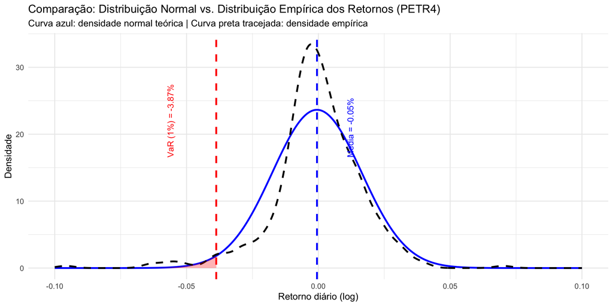

## Interpretação Visual do VaR Paramétrico

**Leitura do Gráfico e Considerações**

- A curva azul representa o **modelo paramétrico** assumido, que, nesse caso, é a distribuição normal.
- A **curva preta tracejada** mostra a distribuição **empírica** dos retornos observados da ação PETR4.
- O **VaR é uma medida de perda potencial**: representa o menor retorno (negativo) que será superado com uma pequena probabilidade, como 1%.
- No gráfico, essa perda está localizada **à esquerda da média** da distribuição normal.
- A **área vermelha sob a curva normal** corresponde à **cauda esquerda com probabilidade $p = 1\%$**, ou seja, há 1% de chance de obter um retorno **ainda pior** que o VaR.
- A **linha vermelha tracejada** marca o ponto de corte: o valor do retorno associado ao quantil de 1%, segundo a distribuição normal.
- Em geral, distribuições empíricas de retornos financeiros apresentam **caudas mais pesadas** (leptocurtose) e **assimetria**.
- Por isso, a suposição de normalidade pode **subestimar o risco de perdas extremas**, tornando o **VaR paramétrico normal menos conservador** que métodos baseados na distribuição empírica.

## VaR - Método Histórico

**Método Histórico (ou Simulação Histórica)**

- O método histórico é uma técnica simples de estimação do risco de perda.  
  Baseia-se na hipótese de que o comportamento dos retornos passados se repetirá no futuro próximo.
- O método consiste em ordenar os retornos históricos do pior para o melhor, e identificar o retorno correspondente ao percentil escolhido (por exemplo, 1%).
- O VaR com probabilidade $p$ é o retorno na posição $T \times p$ da distribuição empírica, multiplicado pelo valor da carteira:

$$VaR_t = - y_{(i)} \cdot \vartheta_t, \quad \text{com } i = \lceil T \cdot p \rceil$$

- Onde $\vartheta_t$ é o valor da carteira no tempo $t$, dado por:

$$\vartheta_t = \text{número de ações} \times P_t$$

- Neste exemplo, adotaremos diretamente o **valor total da carteira**.

## VaR - Método Histórico

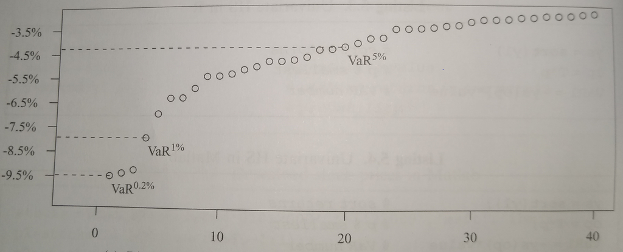

## VaR - Método Histórico

**Simulação Histórica - Algoritmo**

1. Escolha uma probabilidade $p$ (por exemplo, 1%).
2. Obtenha uma amostra de retornos históricos $y$ com tamanho $T$.
3. Ordene os retornos $y$ do menor para o maior.
4. Encontre o índice $i = T \times p$ (arredondado para cima).
5. O VaR é dado por:

$$VaR_t = - y_{(i)} \cdot \vartheta_t, \quad \text{onde } i = \lceil T \cdot p \rceil$$

- Pegamos o $i$-ésimo pior retorno (de menor valor), que representa uma **estimativa conservadora** do quantil de nível $p$ da distribuição empírica.
- Se a carteira vale R$ 1.000 e o retorno na posição $i$ for -3%, então o VaR será de R$ 30 para o horizonte de tempo considerado.

## Método Histórico

**Carteira com 1 Ativo - PETR4**

- Importar os preços da ação PETR4 desde 2024-01-01 com `tq_get()`.
- Calcular os retornos logarítmicos diários da ação:

$$\text{retorno}_t = \log(P_t) - \log(P_{t-1})$$

- Definir o valor da carteira $\vartheta_t$ e a probabilidade $p$;
- Calcular o VaR utilizando a distribuição empírica dos retornos históricos.

## Método Histórico em R

**Estimativa do VaR Histórico - 1 Ação**

```r
# pipeline para importar os preços da ação da Petrobras
# calcular os retornos e remover valores ausentes
precos_petrobras <- "PETR4.SA" %>%
  tq_get(from = "2024-01-01") %>%
  select(date, close) %>%
  mutate(ret_petrobras = log(close / lag(close))) %>%
  drop_na()

# Extrai vetor de retornos
ret_petrobras <- precos_petrobras %>%
  pull(ret_petrobras)

# Parâmetros
valor_carteira <- 1000
p <- 0.01

# Estimação do VaR

# 1. Ordena os retornos crescentemente
ret_petr_ord <- sort(ret_petrobras)

# 2. Encontra o índice correspondente ao quantil de nível p
#    Isto é, o retorno que define a cauda esquerda com p% de probabilidade
#    ceiling() é usada para garantir que pegamos um valor suficientemente extremo
op <- ceiling(length(ret_petr_ord) * p)
op
```

```
[1] 4
```

```r
# 3. VaR histórico monetário: valor correspondente ao retorno mais severo
var_petr_hs <- -ret_petr_ord[op] * valor_carteira
var_petr_hs
```

```
[1] 57.028
```

```r
# 4. VaR histórico percentual
var_percentual_petr_hs <- -ret_petr_ord[op] * 100
var_percentual_petr_hs
```

```
[1] 5.7028
```

## Visualização do VaR Histórico em R

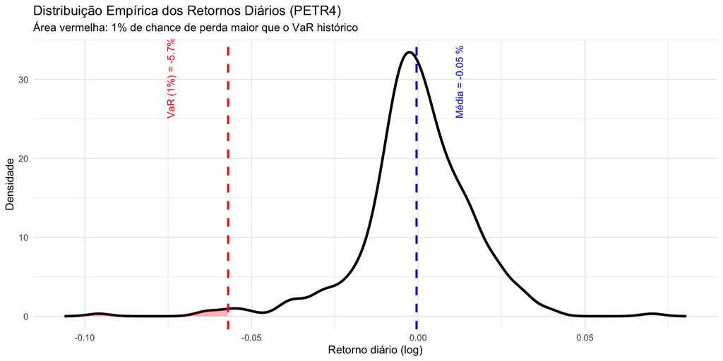

## Método Histórico

**Considerações sobre o Método Histórico**

- A Simulação Histórica é simples e não exige suposições sobre a distribuição dos retornos.
- Retornos extremos podem variar bastante: quanto maior a amostra histórica, mais confiável a estimativa do VaR.
- Uma desvantagem é que eventos passados podem não refletir bem as condições futuras, especialmente em períodos de **quebra estrutural** (como em 2008).
- Regra prática para tamanho mínimo da amostra:

$$T_{\text{mínimo}} \geq \frac{3}{p}$$

## VaR - Método por Simulação de Monte Carlo

**Visão Geral**

- A **Simulação de Monte Carlo** pode ser aplicada de forma:
  - **Paramétrica**: assume uma distribuição de probabilidade (ex: normal);
  - **Não-paramétrica**: utiliza diretamente os dados históricos.
- Neste exemplo, utilizamos a versão **não-paramétrica**, que realiza uma **reamostragem com reposição** (bootstrap) dos retornos históricos da ação, sem supor nenhuma forma funcional específica para a distribuição.
- O método consiste em gerar **cenários simulados de retornos** e estimar o VaR como o quantil empírico correspondente ao nível de probabilidade $p$.

## VaR - Simulação de Monte Carlo

**Algoritmo - Simulação Não-Paramétrica**

1. Escolha um nível de probabilidade $p$ (ex: 1%).
2. Obtenha uma amostra histórica de retornos $y = (y\_1, \dots, y\_T)$.
3. Gere $N$ simulações de retornos por **reamostragem com reposição** de $y$.
4. Ordene os retornos simulados do menor para o maior: $y^{(s)}*{(1)} \leq \dots \leq y^{(s)}*{(N)}$.
5. Encontre o índice $i = \lceil N \cdot p \rceil$.
6. O VaR é dado por:

$$VaR_t = - y^{(s)}_{(i)} \times \vartheta_t$$

onde $\vartheta\_t$ é o valor da carteira no tempo $t$.

- O uso de $\lceil N \cdot p \rceil$ garante uma estimativa conservadora, evitando interpolação ambígua.

## Exemplo: Reamostragem Empírica

**Exemplo**

- Importar os preços da ação PETR4 a partir de 2024-01-01 usando `tq_get()`.
- Calcular os retornos logarítmicos diários:

$$\text{retorno}_t = \log(P_t) - \log(P_{t-1})$$

- Definir o valor da carteira e o nível de significância $p$.
- Estimar o VaR via **reamostragem empírica com reposição** dos retornos históricos.

## Estimativa do VaR (Simulação NP)

**Código - Estimativa do VaR Não-Paramétrico**

```r
# pipeline para importar os preços da ação da Petrobras
# calcular os retornos e remover valores ausentes
precos_petrobras <- "PETR4.SA" %>%
  tq_get(from = "2024-01-01") %>%
  select(date, close) %>%
  mutate(ret_petrobras = log(close / lag(close))) %>%
  drop_na()

# Extrai os retornos
ret_petrobras <- precos_petrobras$ret_petrobras

# Define parâmetros
valor_carteira <- 1000     # valor investido em reais
p <- 0.01                  # nível de significância (1%)
n <- 1000                  # número de simulações

# Simulação de Monte Carlo (não-paramétrica)
set.seed(123)
ret_simulados <- sample(ret_petrobras, size = n, replace = TRUE)

# Ordena os retornos simulados
ret_simulados_ord <- sort(ret_simulados)

# Encontra o índice do quantil
# Usamos ceiling() para garantir uma estimativa conservadora (valor mais extremo)
indice_var <- ceiling(n * p)

# Estima o VaR monetário
var_petr_mc <- -ret_simulados_ord[indice_var] * valor_carteira
var_petr_mc
```

```
[1] 55.821
```

```r
# Estima o VaR percentual
var_percentual_petr_mc <- -ret_simulados_ord[indice_var] * 100
var_percentual_petr_mc
```

```
[1] 5.5821
```

## Visualização do VaR Não-Paramétrico

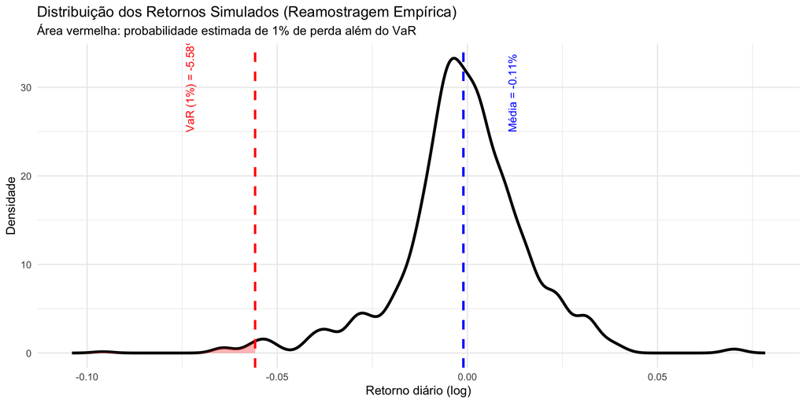

## Visualização do VaR Não-Paramétrico

**Considerações**

- A curva preta representa a **densidade empírica dos retornos simulados** obtidos por reamostragem com reposição (bootstrap).
- A **área vermelha** representa os **1% piores retornos simulados**, ou seja, a cauda esquerda da distribuição com probabilidade $p = 1%$.
- A **linha vermelha tracejada** marca o valor do **VaR estimado**, ou seja, o **menor retorno tal que apenas 1% dos retornos sejam ainda piores**.
- A **linha azul** marca a média dos retornos simulados.
- Essa visualização é análoga à do método histórico, pois ambos são **não-paramétricos** e **não impõem suposições de normalidade**.

## Valor-em-Risco (VaR)

**Resumo do VaR**

- O VaR com nível de probabilidade $p$ representa a **pior perda esperada com probabilidade $1 - p$ de não ser superada.
- Ele é um limite inferior para os piores $100 \cdot p\%$ retornos negativos (perdas).
- **Exemplo**: Com $p = 0.01 = 1\%$, o VaR quantifica a perda que será excedida em média **1 vez a cada 100 dias**.
- **Limitações**:
  - O VaR não é subaditivo;
  - O VaR não mostra **o tamanho da perda além do VaR**;
  - O **Expected Shortfall (ES)** é uma medida alternativa que busca superar essas limitações.

## Expected Shortfall (ES)

**O que é o Expected Shortfall (ES)?**

- Um número de medidas de risco alternativas tem sido proposta para superar os problemas do VaR (falta de **subaditividade** entre eles) do VaR e/ou fornecer mais informaçõs sobre a forma da cauda.

O **Expected Shortfall (ES)**, também chamado de **Conditional Value-at-Risk (CVaR)**, é uma medida de risco que estima a **perda média esperada**, **condicionalmente** ao evento de que a perda exceda o VaR.

- Ele responde à pergunta: “**Qual é perda esperada quando as perdas excedem o VaR?**”
- Enquanto o **VaR** é baseado em um **quantil** da distribuição de perdas, o **ES** é definido como o **valor esperado condicional** das perdas, dado que elas excedem esse quantil:

$$ES = - E[L \mid L \leq VaR_{(p)}]$$

- O ES é uma **medida de risco coerente**, satisfazendo os 4 axiomas de Artzner *et al.* (1999): monotonicidade, subaditividade, homogeneidade positiva e invariância translacional.

## Estimação Empírica do ES

**Como estimamos o ES empiricamente?**

Dado um nível de probabilidade $p$ (ex: 1%), estimamos o **Expected Shortfall** como a média condicional dos piores $p \cdot T$ retornos, onde $T$ é o tamanho da amostra.

- Algoritmo (Histórico):
1. Ordena-se os retornos em ordem crescente: $r_{(1)} \leq r_{(2)} \leq \dots \leq r_{(T)}$
2. Define-se o índice do VaR: $k = \lceil \alpha \cdot T \rceil$
3. O **VaR empírico** é dado por: $VaR\_\alpha = -r\_{(k)}$
4. O **Expected Shortfall empírico** é:

$$ES_\alpha = -\frac{1}{k} \sum_{i=1}^{k} r_{(i)}$$

- Em outras palavras: o ES é a **média dos piores retornos** (mais negativos) da amostra que excedem o VaR.

## Estimação Empírica do ES

**PETR4 — Estimativa Empírica do ES**

```r
# 1. Parâmetros
p <- 0.01
valor_carteira <- 1000

# 2. Ordena os retornos da PETR4
retornos_ordenados <- sort(ret_petrobras)

# 3. Índice do quantil
k <- ceiling(length(retornos_ordenados) * p)

# 4. VaR e ES empíricos (percentuais)
var_percentual <- -retornos_ordenados[k] * 100
es_percentual <- -mean(retornos_ordenados[1:k]) * 100

# 5. Valores monetários
var_monetario <- var_percentual / 100 * valor_carteira
es_monetario <- es_percentual / 100 * valor_carteira

# Resultados
var_monetario
```

```
[1] 57.028
```

```r
es_monetario
```

```
[1] 69.838
```

## Visualização do Expected Shortfall (ES)

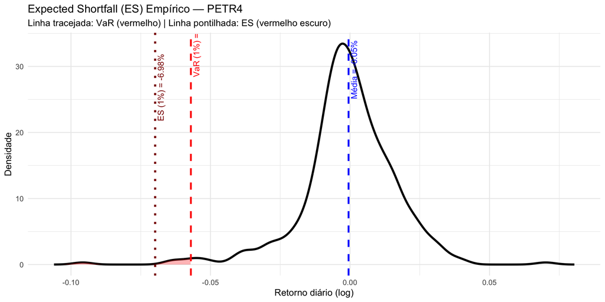

## Expected Shortfall - Interpretação Visual

**VaR vs. ES**

- No gráfico de densidade dos retornos, o **VaR** é representado por uma **linha vertical tracejada vermelha** que separa os **1% piores retornos** (quantil de 1%).
- O **Expected Shortfall** aparece como uma **linha pontilhada** mais à esquerda — representando a **média dos piores retornos**.
- Visualmente, o ES aparece **mais à esquerda do que o VaR** e é **sempre maior em magnitude** (ou seja, mais negativo).
- O ES é sempre **mais conservador** que o VaR.

## Considerações Finais

**Por que o ES é mais informativo que o VaR?**

- O **ES** leva em conta a **severidade das perdas extremas**, não apenas sua ocorrência.
- Ele é mais robusto, pois:
  - Fornece uma estimativa do **comportamento da cauda**
  - Satisfaz os 4 axiomas da **coerência de medidas de risco**
- O **FRTB (Basileia III)** adotou o ES no lugar do VaR como **medida oficial de risco de mercado** para cálculo de capital regulatório.
- O ES complementa e **enriquece a análise de risco** em cenários de perda severa.

# Carteria com 3 Ações

## Retorno da Carteira com 3 Ativos

**Retorno de uma Carteira**

- Seja uma carteira com três ativos, com pesos $(w\_1, w\_2, w\_3)$ associados a cada ação:

| Ação | Ticker | Peso na Carteira ($w_i$) |
| --- | --- | --- |
| Petrobrás | PETR4.SA | $w_1$ |
| Magazine Luiza | MGLU3.SA | $w_2$ |
| Itaú Unibanco | ITUB4.SA | $w_3$ |

- Os retornos diários dos ativos no tempo $t$ são $(r_{1,t}, r_{2,t}, r_{3,t})$.
- O retorno da carteira no tempo $t$** é a média ponderada dos retornos:

$$r_{c,t} = w_1 \cdot r_{1,t} + w_2 \cdot r_{2,t} + w_3 \cdot r_{3,t}$$

- Em notação vetorial:

$$r_{c,t} = \mathbf{w}^\top \mathbf{r}_t
\quad \text{onde }
\mathbf{w} =
\begin{bmatrix}
w_1 \\ w_2 \\ w_3
\end{bmatrix},
\quad
\mathbf{r}_t =
\begin{bmatrix}
r_{1,t} \\ r_{2,t} \\ r_{3,t}
\end{bmatrix}$$

## Variância e Volatilidade da Carteira

**Variância da Carteira**

- A variância dos retornos da carteira, $\text{Var}(r_c)$, é dada por:

$$\text{Var}(r_c) = \mathbf{w}^\top \boldsymbol{\Sigma} \mathbf{w}$$

Onde:

- $\mathbf{w}$ é o vetor de pesos da carteira;
- $\boldsymbol{\Sigma}$ é a matriz de covariância dos retornos dos ativos:

$$\boldsymbol{\Sigma} =
\begin{bmatrix}
\sigma_1^2 & \sigma_{12} & \sigma_{13} \\
\sigma_{21} & \sigma_2^2 & \sigma_{23} \\
\sigma_{31} & \sigma_{32} & \sigma_3^2
\end{bmatrix}$$

- O **desvio-padrão da carteira** é:

$$\sigma_c = \sqrt{\text{Var}(r_c)}$$

- A variância incorpora não apenas a **volatilidade individual**, mas também a **correlação entre os ativos** — capturando o benefício da **diversificação**.

## Retornos da Carteira em R

**Implementação em R**

```r
# Importa as séries de preços das ações
serie_precos <- c("PETR4.SA", "MGLU3.SA", "ITUB4.SA") %>%
  tq_get(from = "2024-01-01") %>%
  select(symbol, date, close) %>%
  pivot_wider(names_from = symbol, values_from = close) %>%
  rename(dia = date,
         petr4 = PETR4.SA,
         mglu3 = MGLU3.SA,
         itub4 = ITUB4.SA)

# Calcula retornos logarítmicos
retornos <- serie_precos %>%
  mutate(
    ret_petr4 = log(petr4 / lag(petr4)),
    ret_mglu3 = log(mglu3 / lag(mglu3)),
    ret_itub4 = log(itub4 / lag(itub4))
  ) %>%
  drop_na()

# Define os pesos
pesos <- c(0.4, 0.3, 0.3)  # exemplo: 40% PETR4, 30% MGLU3, 30% ITUB4

# Calcula o retorno da carteira
retornos <- retornos %>%
  mutate(
    ret_carteira = pesos[1] * ret_petr4 +
                   pesos[2] * ret_mglu3 +
                   pesos[3] * ret_itub4
  )

# dimensão do retorno da carteira
dim(retornos$ret_carteira)
```

[output not shown]

```r
# exibie as primeiras linhas
head(retornos$ret_carteira)
```

```
[1]  0.0015646 -0.0160882  0.0140190  0.0115100  0.0034628  0.0015940
```

## VaR Histórico da Carteira

**Estimativa do VaR — Método Histórico**

```r
# Parâmetros
p <- 0.01
valor_carteira <- 1000

# Ordena retornos da carteira
ret_ordenado <- sort(retornos$ret_carteira)

# Índice do quantil
k <- ceiling(length(ret_ordenado) * p)

# VaR percentual e monetário
var_percentual <- -ret_ordenado[k] * 100
var_monetario <- -ret_ordenado[k] * valor_carteira

var_percentual
```

```
[1] 5.007
```

```r
var_monetario
```

```
[1] 50.07
```

- O **VaR histórico** é a perda mínima entre as **1% piores perdas históricas**.
- Conservador por natureza — não depende de suposições paramétricas.

## Estimativa do Expected Shortfall (ES)

**Estimativa do ES — Média Condicional**

```r
# Expected Shortfall (ES)
es_percentual <- -mean(ret_ordenado[1:k]) * 100
es_monetario <- -mean(ret_ordenado[1:k]) * valor_carteira

es_percentual
```

```
[1] 5.432
```

```r
es_monetario
```

```
[1] 54.32
```

- O **Expected Shortfall** é a **média das perdas mais severas**, ou seja:

$$ES = - \frac{1}{k} \sum_{i=1}^{k} r^{(i)}$$

- O ES sempre **excede (em magnitude)** o VaR — é mais conservador.

## Exercício

**Enunciado**

Você é o analisata responsável por estimar o risco de uma carteira de investimentos formada exclusivamente pelas ações da empresa **Vale S.A. (VALE3.SA)**, usando dados reais do mercado de capitais.

1. Usando o pacote `tidyquant`, importe os preços de fechamento diários da ação **VALE3.SA**, a partir de **01/01/2024**.
2. Calcule os **retornos logarítmicos diários** da ação.
3. Suponha que o valor da carteira seja de **R$ 5.000**.
4. Estime o **Value-at-Risk (VaR)** e o **Expected Shortfall (ES)** para a carteira, no nível de probabilidade de **5%**, utilizando o **método histórico**.
5. Interprete os valores obtidos: o que eles indicam sobre o risco da carteira?

## Referências

ARTZNER, P. *et al.* [Coherent Measures of Risk](https://doi.org/10.1111/1467-9965.00068). **Mathematical Finance**, v. 9, n. 3, p. 203–228, 1999.

HARDAKER, J. B. *et al.* **Coping with Risk in Agriculture**. 2. ed. Wallingford, UK: CABI Publishing, 2004. p. 332

KANITZ, S. C. **Como Prever Falências**. São Paulo: McGraw-Hill do Brasil, 1978.

RICHARDSON, J. W.; KLOSE, S. L.; GRAY, A. W. [An applied procedure for estimating and simulating multivariate empirical (MVE) probability distributions in farm-level risk assessment and policy analysis](https://doi.org/10.1017/S107407080002037X). **Journal of Agricultural and Applied Economics**, v. 32, n. 2, p. 299–315, 2000.

## Atualizando os Repositórios

**Instruções**

1. No terminal do RStudio, verifique quais arquivos/pastas foram modificados ou criados com:

```bash
git status
```

2. Você pode adicionar todos os arquivos de uma vez com:

```bash
git add .
```

3. Execute git status novamente para confirmar que todos os arquivos foram adicionados (aparecerão em verde sob “*Changes to be committed*”):

```bash
git status
```

4. Se tudo estiver em verde, faça um commit com uma mensagem descritiva:

```bash
git commit -m "atualizacoes aula 10"
```

5. Se algum arquivo ou pasta ainda aparecer em vermelho após o segundo git status, adicione as pastas/arquivos um por um:

```bash
git add relatorios/08-relatorio/08-relatorio.qmd
```

6. Execute git status novamente e faça o commit quando todos os arquivos estiverem em verde:

```bash
git commit -m "atualizacoes aula 10"
```

7. Envie o repositório local atualizado para o GitHub:

```bash
git push origin main
```